# USW Computational Basics - Skriptum

# Kapitel 7 - Zufallszahlen - ein Energiemix

In den bisher betrachteten Beispielen systemwissenschaftlicher Modellbildung sind wir davon ausgegangen, dass wir die Daten, die wir dafür benötigen, kennen, dass wir also zum Beispiel wissen, wie groß die Wachstumsrate oder auch die Anfangsgröße einer Tierpopulation ist. Dies ist leider aber nicht immer der Fall. Oftmals haben wir bestenfalls eine mehr oder wenigerer gute Vorstellung über ein Intervall, innerhalb dessen sich die benötigten Daten bewegen. In diesen Fällen können wir **Zufallszahlen** heranziehen, um unser Modell an realistische Gegebenheiten anzunähern. Zum Glück stellt uns auch dafür Python die nötigen Werkzeuge zur Verfügung.

Um dies zu demonstrieren, wollen wir uns im Folgenden mit einem Energienetzwerk beschäftigen, bestehend aus Wind-, Wasser- und Kohlekraftwerken. Wir werden die Produktion dieser Kraftwerke dem Verbrauch gegenüberstellen und Strategien finden, wie man den Bedarf möglichst gut decken kann, und möglichst wenig fossile Brennstoffe verwenden zu müssen.

Wir beginnen unser diesbezügliches Modell ganz einfach mit einer For-Schleife, die Stunde für Stunde über den Simulationszeitraum iteriert. In dieses Grundgerüst bauen wir auch schon ein Wasserkraftwerk ein, das konstant Strom liefert. Um den produzierten Strom grafisch darzustellen, verwenden wir einen so genannten `Stack-Plot`:

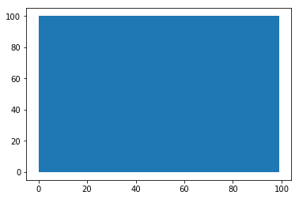

```python
import matplotlib.pyplot as plt
%matplotlib inline

simulationszeit = 100
wasserkraft_liste = []

for zeit in range(simulationszeit):
    wasserkraft = 100
    wasserkraft_liste.append(wasserkraft)

plt.stackplot(range(simulationszeit), wasserkraft_liste)
```

Ein Wasserkraftwerk, das konstant die selbe Menge Strom liefert ist zwar parktisch, leider aber nicht realistisch. In der Realität wird es immer kleine Schwankungen geben, die wir auch in unsere Simulation einbauen sollten. Dazu benutzen wir **Zufallszahlen**.

Für unser Wasserkraftwerk nehmen wir an, dass die Leistung meistens etwa 100 MW beträgt. Kleine Abweichungen werden häufiger sein, große Abweichungen seltener. Wir haben es also mit einer so genannten **Normal-** oder auch **Gauß-Verteilung** zu tun. Gauß-verteilte Zufallszahlen generiert man in Python mit dem Befehl `random.gauss(mittelwert, standardabweichung)` aus dem Packet `random`, das wir zunächst importieren müssen. Als Mittelwert verwenden wir 1 (mal 100 MW), als Standardabweichung können wir 0.1 benutzen (also 10%). Vereinfacht gesagt heißt das, dass die Zahlen, die damit generiert werden, im Durchschnitt 10% vom Mittelwert entfernt liegen, und zwar, je größer die Abweichung ist, umso seltener.

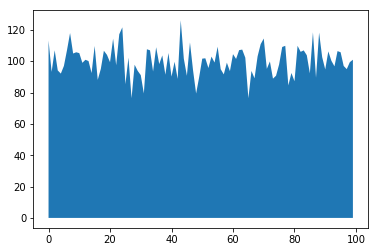

```python
import matplotlib.pyplot as plt
import random
%matplotlib inline

simulationszeit = 100
wasserkraft_liste = []

for zeit in range(simulationszeit):
    wasserkraft = 100 * random.gauss(1, 0.1)
    wasserkraft_liste.append(wasserkraft)

plt.stackplot(range(simulationszeit), wasserkraft_liste)
```

Neben einem Wasserkraftwerk möchten wir nun auch ein Windkraftwerk in unser Stromnetz einbauen. Die Leistung von Windkraftwerken ist stärker vom Zufall abhängig: bei Windstille produzieren sie gar nichts, aber auch zu starker Wind macht ihnen Probleme. Ein Gauß-Verteilung ist hier also nicht sinnvoll, wenn wir abbilden wollen, dass ein Windkraftwerk hin und wieder auch keinen Strom liefert.

Wir können dazu aber **gleich-verteilte** Zufallszahlen heranziehen. Bei gleichverteilten Zufallszahlen ist jede Zahl gleich wahrscheinlich. Der folgende Plot illustriert den Unterschied zwischen Gauß-verteilten und gleich-verteilten Zufallszahlen. Wir verwenden den Befehl `random.uniform(0, 20)`, um reelle Zahlen zwischen 0 und (ausschließlich) 20 zu erzeugen. Diese werden zu 90 hinzu addiert, um eine ebenfalls um 100 variierende Verteilung zu erzeugen. Zum Plotten verwenden wir hier den Befehl `hist`, der ein Histogramm der erzeugten Daten zeichnet.

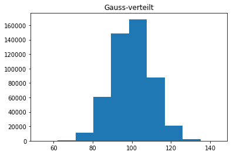

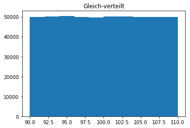

```python
gauss=[]
gleich=[]

for it in range(500000):
    gauss.append(random.gauss(100, 10))
    gleich.append(90 + random.uniform(0, 20))

plt.hist(gauss)
plt.title('Gauss-verteilt')

plt.figure()
plt.hist(gleich);
plt.title('Gleich-verteilt')
```

Unser Windkraftwerk soll eine maximale Leistung von 7 MW besitzen. Bei Windstille kann es aber vorkommen, dass auch gar kein Strom geliefert wird. Wir verwenden für die Leistung des Windkraftwerks also eine Zufallszahl zwischen 0 und 7, die wir mit dem Befehl `random.uniform()` erzeugen. Pythons **Stackplot** liefert uns die bequeme Möglichkeit, die zusätzlich zu den 100% Wasserkraft erzeugte Windenergie einfach grafisch auf die Wasserkraft auf zu addieren. Zur Unterscheidung der beiden Energiearten verwenden wir zwei unterschiedliche Blautöne: `darkblue` und `skyblue`.

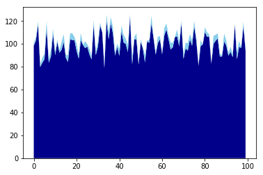

```python
import matplotlib.pyplot as plt
import random
%matplotlib inline

simulationszeit = 100
wasserkraft_liste = []
windkraft_liste = []

for zeit in range(simulationszeit):
    wasserkraft = 100 * random.gauss(1, 0.1)
    wasserkraft_liste.append(wasserkraft)
    windkraft = random.uniform(0, 7)
    windkraft_liste.append(windkraft)

# '#cceeff' steht für ein etwas helleres blau
plt.stackplot(range(simulationszeit), wasserkraft_liste, windkraft_liste, colors = ('darkblue', 'skyblue'))
```

Wir sehen, dass der Beitrag eines einzelnen Windkraftwerks, im Vergleich zu einem Wasserkraftwerk, nur eher wenig ausmacht. Wir sollten unser Modell also ausbauen, sodass wir die Zahl der jeweiligen Kraftwerke bestimmen können. Das wird es uns später erlauben zu bestimmen, wie viele Kraftwerke wir von welchem Typ benötigen.

Wir gehen hier im Folgenden zunächst von 10 Windkraftwerken und einem Wasserkarftwerk aus.

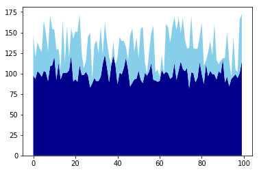

```python
import matplotlib.pyplot as plt
import random
%matplotlib inline

simulationszeit = 100
windkraft_anzahl = 10
wasserkraft_anzahl = 1

wasserkraft_liste = []
windkraft_liste = []

for zeit in range(simulationszeit):
    wasserkraft = wasserkraft_anzahl * 100 * random.gauss(1, 0.1)
    wasserkraft_liste.append(wasserkraft)
    windkraft = windkraft_anzahl * random.uniform(0, 7)
    windkraft_liste.append(windkraft)

plt.stackplot(range(simulationszeit), wasserkraft_liste, windkraft_liste, colors=('darkblue', 'skyblue'))
```

Sollten wir nun als Vorgabe haben, dass zu jeder Zeit mindestens 150 MW Strom verfügbar sein sollen, so sehen wir, dass die Anzahl unserer Windkraftwerke noch nicht ausreicht:

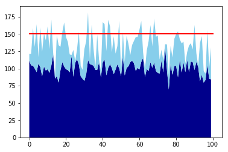

```python
import matplotlib.pyplot as plt
import random
%matplotlib inline

simulationszeit = 100
windkraft_anzahl = 10
wasserkraft_anzahl = 1

wasserkraft_liste = []
windkraft_liste = []

for zeit in range(simulationszeit):
    wasserkraft = wasserkraft_anzahl * 100 * random.gauss(1, 0.1)
    wasserkraft_liste.append(wasserkraft)
    windkraft = windkraft_anzahl * random.uniform(0, 7)
    windkraft_liste.append(windkraft)

plt.stackplot(range(simulationszeit), wasserkraft_liste, windkraft_liste, colors = ('darkblue', 'skyblue'))
# zeichne eine rote Linie in der Höhe von 150
plt.plot((0, 100),(150, 150), c = "red", lw = 2)
```

Wir müssen die Anzahl an Windkraftwerken also noch ein wenig erhöhen:

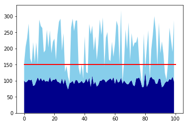

```python
import matplotlib.pyplot as plt
import random
%matplotlib inline

simulationszeit = 100
windkraft_anzahl = 30
wasserkraft_anzahl = 1



wasserkraft_liste = []
windkraft_liste = []

for zeit in range(simulationszeit):
    wasserkraft = wasserkraft_anzahl * 100 * random.gauss(1, 0.1)
    wasserkraft_liste.append(wasserkraft)
    windkraft = windkraft_anzahl * random.uniform(0, 7)
    windkraft_liste.append(windkraft)

plt.stackplot(range(simulationszeit), wasserkraft_liste, windkraft_liste, colors = ('darkblue', 'skyblue'))
plt.plot((0, 100), (150, 150), c = "red", lw = 2)
```

Wir sehen, dass, auch wenn wir 30 Windkraftwerke vorsehen und wir damit zu manchen Zeiten doppelt so viel Strom produzieren wie benötigt, es immer noch Zeiten gibt, zu denen wir die 150 MW Marke nicht erreichen. Wo liegt das Problem?

Das Problem liegt in der Eigenart der Windenergie. Bei Windstille produziert keines der 30 Windkraftwerke Strom. Wir haben beim Erstellen unseres Modells implizit angenommen, dass alle Windkraftwerke in der selben Region liegen und damit von den selben Windverhältnissen betroffen sind. In unserem Programmcode verwenden alle Kraftwerke die gleiche Zufallszahl: Wenn also in einer Stunde "Windstille" gewürfelt wird, dann gilt das für alle Kraftwerke.

Wir könnten aber auch annehmen, dass die Krafwerke so weit voneinander entfernt stehen, dass es für jedes Kraftwerk andere Windverhältnisse gibt. Aber ändert das etwas? Wird dann im Mittel nicht genau gleich viel Strom produziert?

Probieren wir es aus: Ändern wir unser Programm, sodass für jedes Kraftwerk eine eigene Zufallszahl vorgibt, wieviel Strom gerade produziert wird.

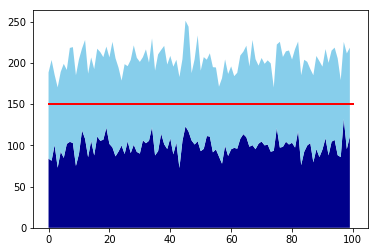

```python
import matplotlib.pyplot as plt
import random
%matplotlib inline

simulationszeit = 100
windkraft_anzahl = 30
wasserkraft_anzahl = 1

wasserkraft_liste = []
windkraft_liste = []

for zeit in range(simulationszeit):
    wasserkraft = wasserkraft_anzahl * 100 * random.gauss(1, 0.1)
    wasserkraft_liste.append(wasserkraft)
    windkraft = 0
    for kraftwerke in range(windkraft_anzahl):
        windkraft = windkraft + random.uniform(0, 7)
    windkraft_liste.append(windkraft)

plt.stackplot(range(simulationszeit), wasserkraft_liste, windkraft_liste, colors = ('darkblue', 'skyblue'))
plt.plot((0, 100), (150, 150), c = "red", lw = 2)
```

Wir sehen: obwohl im Mittel gleich viel Strom produziert wird, macht die Annahme, dass die Windkraftwerke von unterschiedlichen Windverhältnissen betroffen sind, einen großen Unterschied: wenn wir für jedes Kraftwerk eine eigene Zufallszahl erzeugen, mittelt sich das Ergebnis besser. Es gibt weniger Spitzen und weniger Senken, die Stromproduktion ist näher am Mittelwert.

Das ist eine grundlegende Eigenschaft von Zufallszahlen: Wenn man sehr viele davon verwendet, ist das Ergebnis immer sehr nahe am Mittelwert der möglichen Resultate.

Mit dem nun vorliegenden Modell schaut es also so aus, als würden wir sicherstellen können, dass immer 150 MW Strom verfügbar sind. Was passiert aber, wenn wir miteinbeziehen, dass Windkraftwerke einmal defekt werden können? Wie bauen wir so ein Zufallsereignis in unsere Simulation ein?

### Zufallsereignisse mit Python

Wir haben bisher gelernt, wie man zufällige Zahlen erstellt. Was aber, wenn wir keine Zahl erzeugen wollen, sondern ein Ereignis - z.B. einen Defekt in einem Windkraftwerk -, das mit bestimmter Wahrscheinlichkeit auftritt? Wir können dazu Zufallszahlen mit `If-Abfragen` kombinieren.

Dazu benutzen wir den Umstand, dass 10% der Zahlen von 1 bis 100 kleiner oder gleich 10 sind. Und 50% der Zahlen sind kleinergleich 50. Im Code könnten wir also schreiben:

```python
chance = 50
zufallszahl = random.uniform(0, 100)
if zufallszahl <= chance:
    print("KOPF!")
else:
    print("ZAHL!")
```

```
KOPF!
```

Das heißt, wir vergleichen hier die prozentuelle Chance eines Zufallsereignisses mit einer Zufallszahl und können somit sicher sein, dass dieses Ereignis auch mit genau dieser Chance passiert.

Bauen wir so eine Chance in unsere Simulation ein. Wir nehmen an, dass jede Stunde eine 10%-Chance besteht, dass ein Defekt im Windkraftwerk für einen Ausfall der Stromversorgung sorgt:

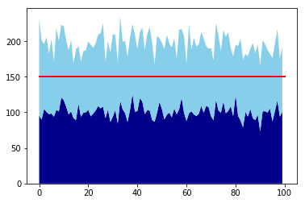

```python
import matplotlib.pyplot as plt
import random
%matplotlib inline

simulationszeit = 100
windkraft_anzahl = 30
wasserkraft_anzahl = 1

wasserkraft_liste = []
windkraft_liste = []

for zeit in range(simulationszeit):
    wasserkraft = wasserkraft_anzahl * 100 * random.gauss(1, 0.1)
    wasserkraft_liste.append(wasserkraft)
    windkraft = 0
    for kraftwerke in range(windkraft_anzahl):
        if random.uniform(0, 100) <= 10:
            # STÖRUNG: kein Strom wird produziert
            windkraft = windkraft + 0
        else:
            # Normalbetrieb:
            windkraft = windkraft + random.uniform(0, 7)
    windkraft_liste.append(windkraft)

plt.stackplot(range(simulationszeit), wasserkraft_liste, windkraft_liste, colors = ('darkblue', 'skyblue'))
plt.plot((0, 100), (150, 150), c = "red", lw = 2)
```

Wir sehen, dass wir, obwohl es manchmal schon knapp wird, die Stromversorgung meistens noch sicherstellen können. Erhöhen wir aber die Ausfallchance zum Beispiel auf 50%, so sieht die Sache anders aus.

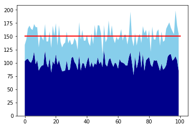

```python
import matplotlib.pyplot as plt
import random
%matplotlib inline

simulationszeit = 100
windkraft_anzahl = 30
wasserkraft_anzahl = 1

wasserkraft_liste = []
windkraft_liste = []

for zeit in range(simulationszeit):
    wasserkraft = wasserkraft_anzahl * 100 * random.gauss(1, 0.1)
    wasserkraft_liste.append(wasserkraft)
    windkraft = 0
    for kraftwerke in range(windkraft_anzahl):
        if random.uniform(0, 100) <= 50:
            # STÖRUNG: kein Strom wird produziert
            windkraft = windkraft + 0
        else:
            # Normalbetrieb:
            windkraft = windkraft + random.uniform(0, 7)
    windkraft_liste.append(windkraft)

plt.stackplot(range(simulationszeit), wasserkraft_liste, windkraft_liste, colors = ('darkblue', 'skyblue'))
plt.plot((0, 100), (150, 150), c = "red", lw = 2)
```

Um noch etwas mehr über Zufallsgeneratoren zu lernen, wollen wir im Folgenden noch ein weiteres Kraftwerk in unser Stromnetz einbauen. Wir nehmen dazu ein eher unzuverlässiges Kohlekraftwerk an, das nur drei Betriebsmodi hat: "Stillstand" (0 MW), "Normalbetrieb" (20 MW) und "Hochbetrieb" (70 MW). In unserem Beispiel treten diese drei Betriebsmodi zufällig auf, kein anderer MW-Wert kann produziert werden.

Wie würden wir das am besten umsetzen? Eine Zufallszahl zwischen 0 und 70 wäre schon einmal falsch, 3 aufeinanderfolgende 33%-Chancen wären auch nicht richtig, da in dem Fall ja mehrere Betriebsmodi auf einmal möglich wären. In Pyhton gibt es glücklichweise eine ganz einfache Lösung für solche Probleme: der Befehl `random.choice((a, b, c))` trifft eine zufällige Entscheidung zwischen a, b und c, wobei a, b und c nicht einmal Zahlen sein müssen. Bauen wir damit das Kraftwerk in unsere Simulation ein.

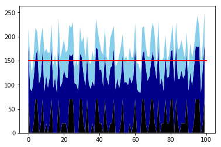

```python
import matplotlib.pyplot as plt
import random
%matplotlib inline

simulationszeit = 100
windkraft_anzahl = 30
wasserkraft_anzahl = 1



wasserkraft_liste = []
windkraft_liste = []
kohlekraft_liste = []

for zeit in range(simulationszeit):
    wasserkraft = wasserkraft_anzahl * 100 * random.gauss(1, 0.1)
    wasserkraft_liste.append(wasserkraft)
    windkraft = 0
    for kraftwerke in range(windkraft_anzahl):
        if random.uniform(0, 100) <= 50:
            # STÖRUNG: kein Strom wird produziert
            windkraft = windkraft + 0
        else:
            # Normalbetrieb:
            windkraft = windkraft + random.uniform(0, 7)
    windkraft_liste.append(windkraft)

    kohlekraft = random.choice((0, 20, 70))
    kohlekraft_liste.append(kohlekraft)

plt.stackplot(range(simulationszeit), kohlekraft_liste, wasserkraft_liste, windkraft_liste,
              colors = ('black', 'darkblue','skyblue'))
plt.plot((0, 100), (150, 150), c = "red", lw = 2)
```

Freilich gibt es noch Probleme, die wir mit unserer bisherigen Kenntnis von Zufallszahlen noch nicht darstellen können: Nehmen wir etwa an, es gäbe innerhalb des Simulationszeitraumes eine Stunde, in der das Stromnetz eine besondere Last erfährt. Der Verbrauch steigt hierbei auf 200 MW. Wir wissen jedoch nicht, wann genau diese Stunde sein wird, wir wissen nur dass es eine solche Stunde gibt.

Wäre diese Stunde ganz am Anfang der Simulationszeit, wäre es ein einfaches Problem:

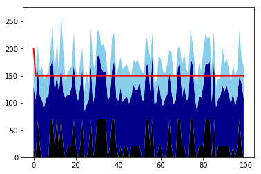

```python
import matplotlib.pyplot as plt
import random
%matplotlib inline

simulationszeit = 100
windkraft_anzahl = 30
wasserkraft_anzahl = 1



wasserkraft_liste = []
windkraft_liste = []
kohlekraft_liste = []
verbrauch_liste = []

for zeit in range(simulationszeit):
    verbrauch_liste.append(150)
    wasserkraft = wasserkraft_anzahl * 100 * random.gauss(1, 0.1)
    wasserkraft_liste.append(wasserkraft)
    windkraft = 0
    for kraftwerke in range(windkraft_anzahl):
        if random.uniform(0, 100) <= 50:
            # STÖRUNG: kein Strom wird produziert
            windkraft = windkraft + 0
        else:
            #Normalbetrieb:
            windkraft = windkraft + random.uniform(0, 7)
    windkraft_liste.append(windkraft)

    kohlekraft= random.choice((0, 20, 70))
    kohlekraft_liste.append(kohlekraft)

plt.stackplot(range(simulationszeit), kohlekraft_liste, wasserkraft_liste, windkraft_liste,
              colors = ('black', 'darkblue', 'skyblue'))

#erstes element von verbrauch_liste auf 200 setzen:
verbrauch_liste[0] = 200

plt.plot(verbrauch_liste, c= "red", lw = 2)
```

Was aber, wenn diese überhöhte Energienachfrage einfach irgendwann auftritt? In diesem Fall hilft uns der Python-Befehl `random.shuffle(liste)`. Dieser mischt die Einträge einer Liste durcheinander. Damit kann man nicht nur Karten mischen...

```python
karten = ['Herz 2', 'Herz 3', 'Herz 4','Herz 5','Herz 6','Herz 7']
random.shuffle(karten)
print(karten)
```

```
['Herz 3', 'Herz 6', 'Herz 7', 'Herz 2', 'Herz 5', 'Herz 4']
```

... sondern auch unser oben genanntes Problem lösen:

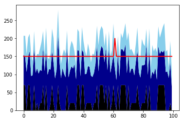

```python
import matplotlib.pyplot as plt
import random
%matplotlib inline

simulationszeit = 100
windkraft_anzahl = 30
wasserkraft_anzahl = 1

wasserkraft_liste = []
windkraft_liste = []
kohlekraft_liste = []
verbrauch_liste = []

for zeit in range(simulationszeit):
    verbrauch_liste.append(150)
    wasserkraft = wasserkraft_anzahl * 100 * random.gauss(1, 0.1)
    wasserkraft_liste.append(wasserkraft)
    windkraft = 0
    for kraftwerke in range(windkraft_anzahl):
        if random.uniform(0, 100) <= 50:
            # STÖRUNG: kein Strom wird produziert
            windkraft = windkraft + 0
        else:
            # Normalbetrieb:
            windkraft = windkraft + random.uniform(0, 7)
    windkraft_liste.append(windkraft)

    kohlekraft= random.choice((0, 20, 70))
    kohlekraft_liste.append(kohlekraft)

plt.stackplot(range(simulationszeit), kohlekraft_liste, wasserkraft_liste, windkraft_liste,
              colors=('black','darkblue','skyblue'))

# erstes Element der verbrauch_liste auf 200 setzen:
verbrauch_liste[0]=200
# shuffeln der gesamten Liste
random.shuffle(verbrauch_liste)

plt.plot(verbrauch_liste, c = "red", lw = 2)
```

## Zusammenfassung

### Zufallszahlen

Zufallszahlen werden in Python mit dem Paket `random` generiert. Es gibt verschiedene Befehle, die unterschiedliche Verteilungen von Zufallszahlen erzeugen.

**Gleich-verteilte (reelle) Zufallszahlen** erstellt man mit `random.uniform(a, b)`, wobei `a` die kleinste mögliche Zahl ist und `b` die obere Grenze markiert, bis zu der (aber ausschließlich der) Zufallszahlen erzeugt werden. Alle Zahlen von `a` bis (exklusive) `b` treten gleich wahrscheinlich auf. Somit lassen sich auch prozentuelle Wahrscheinlichkeiten leicht implementieren: Da 10% aller Zahlen zwischen 0 und 100 kleiner als 10 sind, und in gleichverteilten Zufallszahlen alle Zahlen gleich wahrscheinlich sind, wird die if-Abfrage `if random.uniform(0, 100) < 10` in etwa 10 Prozent der Fälle `true` liefern.

**Normal-verteilte Zufallszahlen** erstellt man mit `random.gauss(m, s)`, wobei `m` den Mittelwert der erzeugten Verteilung angibt und `s` die Standardabweichung. Der genaue Wertebereich ist also schwer abzuschätzen, auch bei `random.gauss(100, 10)` ist es theoretisch möglich, einen Wert kleiner als 50 zu bekommen. Die Chance dafür ist aber verschwindend gering. Je näher die Zahl am Mittelwert ist, umso wahrscheinlicher tritt sie auf. Rund 70% der Werte werden im Intervall m $\pm$ s liegen, also in diesem Beispiel zwischen 90 und 110. Etwa 95% liegen im Intervall m $\pm$ 2s (also 80 bis 120) und über 99% im Intervall m $\pm$ 3s (also 70 bis 130).

Bei jedem Aufruf einer Zufallsfunktion wird eine neue Zahl generiert. Wenn man ein Programm mit Zufallszahlen mehrmals hintereinander ausführt, bekommt man im Allgemeinen unterschiedliche Ergebnisse.

**Zufallsereignisse** Auch zufällige Ereignisse erzeugt man am besten mit Zufallszahlen: Da x% aller Zahlen von 1 bis 100 kleiner sind als x, können wir mit `if random.uniform(0, 100) <= chance` jede beliebige prozentuelle Chance simulieren.

**Random Choice** `random.choice` wählt ein zufälliges Element von mehreren Elementen aus. Jedes Element ist gleich wahrscheinlich und die Elemente müssen nicht zwangsläufig Zahlen sein.

**Random Shuffle** `random.shuffle` mischt eine Liste. Die Elemente bleiben gleich, die Position der Elemente ändert sich. Das ist hilfreich, wenn bekannt ist, welcher Wert der Liste wie oft auftritt, die genaue Position des Wertes aber zufällig sein soll.

### Histogramme

Listen, die aus vielen Zahlen bestehen, können wir als Histogramme darstellen. Histogramme zeigen uns welche Zahlenbereiche häufiger vorkommen udn welche weniger häufig. Ein großer Balken in einem Hisogramm zeigt als **nicht**, dass die Zahl groß ist, sondern dass Zahlen aus diesem Bereich **häufig** sind. Histogramme erstellt man mit `plt.hist(NameDerListe)`

## Kapitel 8 - Vektoren und Matrizen – Die Bewirtschaftung eines Waldes

Eine sehr zentrale Methode für den Umgang mit Daten und Inhalten in den Systemwissenschaften stellt das Rechnen mit Vektoren und Matrizen dar. Python bietet auch hierfür die benötigten Werkzeuge. Um diese kennenzulernen, beschäftigen wir uns im folgenden Beispiel mit der nachhaltigen Bewirtschaftung eines Waldes. Uns interessiert insbesondere, wie der Wald (nach)wächst.

Beginnen wir mit einem ganz einfachen, eindimensionalem Wald-Modell: Wir betrachten also nur eine "Reihe" von Bäumen. In unserem Modell brauchen Bäume Platz um gut wachsen zu können, zwei Bäume dürfen also nie an benachbarten Stellen stehen. Dazu legen wir mit Python eine Liste an, in die wir eine Eins schreiben, wenn sich an einer entsprechenden Stelle ein Baum befindet, und eine Null, wenn nicht. Der Einfachheit halber wechseln wir zunächst einfach ab: Baum, kein Baum, Baum, kein Baum,....

```
<Container object of 30 artists>
```

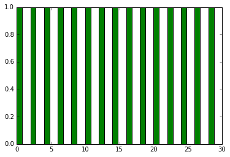

```python
import matplotlib.pyplot as plt
%matplotlib inline

wald1d = []

for posx in range(15):
    wald1d.append(1)
    wald1d.append(0)

plt.bar(range(len(wald1d)), wald1d, color='green')
```

So sieht der Wald aber noch sehr "künstlich" aus. Wir könnten den Wald auch ein wenig zufälliger wachsen lassen: Wir könnten links beginnen und dann Feld für Feld mit einer gewissen Wahrscheinlichkeit einen Baum wachsen lassen:

```
<Container object of 30 artists>
```

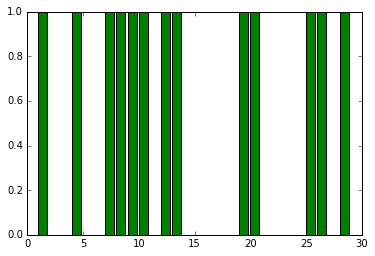

```python
import matplotlib.pyplot as plt
# ein Paket zum Erzeugen von und Rechnen mit Zufallszahlen
import random
%matplotlib inline

wald1d = []


for posx in range(30):
    if random.uniform(0, 100) <= 50:
        wald1d.append(1)
    else:
        wald1d.append(0)

plt.bar(range(len(wald1d)), wald1d, color = 'green')
```

So sieht der Wald zwar zufällig aus, aber noch nicht richtig natürlich: Bäume wachsen nicht so gerne direkt nebeneinander, da sie sich dabei gegenseitig Schatten machen. Wie können wir diesen Umstand in unser Waldmodell einbauen? Die Wahrscheinlichkeit, dass an einer bestimmten Position ein Baum wachsen kann, hängt scheinbar davon ab, ob an der Position daneben schon ein Baum steht oder nicht. Für die Entscheidung für einen Baum an Position `x`, brauchen wir also Daten zu Position `x - 1`.

Dies ist kein Problem. Wir haben unseren ganzen Wald in einer Liste, also mathematisch gesehen in einem **Vektor** gespeichert. Wir erhalten diese Information also, indem wir einfach das je vorherige Vektorelement betrachten. Nehmen wir an, dass ein Baum nur noch eine 20%-Chance hat zu wachsen, wenn an der vorhergehenden Position schon ein Baum steht. Dagegen könnte die Chance auf 90% steigen, wenn das Nachbarfeld frei ist. Das könnten wir wie folgt in unseren Python-Code einbauen:

```
<Container object of 30 artists>
```

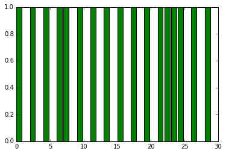

```python
import matplotlib.pyplot as plt
import random
%matplotlib inline

wald1d = [1]

for posx in range(1, 30):
    # Beachte: das Zeichen == steht in den meisten Programmiersprachen für eine tatsächliche Gleichheit,
    # während das Zeichen = für eine Zuweisung eines Werte zu einer Variable steht.
    if wald1d[posx - 1] == 1:
        if random.uniform(0,100) <= 20:
            wald1d.append(1)
        else:
            wald1d.append(0)
    else:
        if random.uniform(0,100) <= 90:
            wald1d.append(1)
        else:
            wald1d.append(0)
plt.bar(range(len(wald1d)), wald1d, color = 'green')
```

Das wäre also unser ein-dimensionaler Wald. Wir wollen ihn nun auf zwei Dimensionen erweitern.

Bisher haben wir unseren "Wald" in einer Liste, bzw. mathematisch in einem **Vektor** gespeichert. In der Mathematik ist ein Vektor ein Schema aus *untereinanderstehenden* Zahlen. Ein ganzer Wald besteht aber in der Regel aus mehreren Reihen von Bäumen. Um ihn darzustellen, benötigen wir für jede Baumreihe einen eigenen Vektor. Einfacher und übersichtlicher ist es, wenn wir diese Zahlenreihen nebeneinanderschreiben. Damit entsteht ein zweidimensionales Zahlenschema, eine sogenannte **Matrix**:

Ein 4x4 Wald in Vektorschreibweise: $$\vec{v_1}= \left( \begin{array}{c} 1\\ 0\\ 0\\ 1\\ \end{array}\right)\ \ \ \ \ \vec{v_2}= \left( \begin{array}{c} 1\\ 1\\ 0\\ 1\\ \end{array}\right)\ \ \ \ \ \vec{v_3}= \left( \begin{array}{c} 0\\ 0\\ 1\\ 0\\ \end{array}\right)\ \ \ \ \ \vec{v_4}= \left( \begin{array}{c} 1\\ 0\\ 1\\ 0\\ \end{array}\right) $$

Der selbe 4x4 Wald in Matrixschreibweise: $$\vec{v_1}= \left( \begin{array}{c c c} 1&1&0&1\\ 0&1&0&0\\ 0&0&1&1\\ 1&1&0&0\\ \end{array}\right)$$

Eine Matrix ist im Prinzip nichts anderes, als eine Liste von Listen. Mit dem Python-Paket `numpy` bekommen wir Zugriff auf zahlreiche "Werkzeuge" zum erleichterten Arbeiten mit Matrizen. Das Anlegen einer leeren 4x4 Matrix würde beispielsweise ohne `numpy` so aussehen:

`wald2d = [[0,0,0,0], [0,0,0,0], [0,0,0,0], [0,0,0,0]]`

was für größere Matrizen zunehmend unübersichtlich würde. Einfacher geht es mit `numpy`:

`wald2d = np.zeros([4,4])`

Das Lesen und Ändern von Matrixeinträgen funktioniert ähnlich wie das Lesen und Ändern von Vektor-, sprich Listenelementen: Der erste Eintrag eines Vektors (einer Liste) ist der Eintrag `vektorname[0]`. In einer Matrize lautet der erste Eintrag links oben `matrixname[0][0]`.

Wenden wir dieses Wissen über Matritzen jetzt auf unser Waldmodell an: Erstellen wir zuerst einen leeren Wald, also eine 10x10 Matrix, die mit Nullen gefüllt ist.

Im nächsten Schritt sollte an jede Stelle eine zufällige Zahl (entweder 1 oder 0) gesetzt werden. `int(random.uniform(0, 2)` erzeugt uns genau so eine Zahl (genaugenommen eine Zahle zwischen 0 und 2, die dann abgerundet wird). Aber wie machen wir das für jeden Eintrag der Matrix?

Der Befehl ist immer der gleiche, aber das Ziel des Befehls ändert sich fortlaufend, nämlich vom Element `[0][0]`, zu `[0][1]`, zu `[0][2]` und so weiter. Um also alle Matrizenstellen mit Zufallszahlen füllen, macht es Sinn eine sogenannte **Doppelschleife** zu verwenden.

Eine Doppelschleife ist eine Schleife innerhalb einer Schleife. Die innere Schleife führt den gewünschten Befehl für eine ganze Zeile der Matrix aus, die äußere Schleife sorgt dafür, dass die innere Schleife für jede Zeile ausgeführt wird. Wichtig dabei ist, dass die Durchlaufvariablen (`it`) nicht den gleichen Namen haben dürfen.

Wenn der Wald fertig erstellt ist, geben wir ihn mit einem einfachen Printbefehl an den Bildschirm aus.

```python
import matplotlib.pyplot as plt
import random
import numpy as np
%matplotlib inline

# erzeuge eine 'leere', sprich mit Nullen gefüllte Matrix
wald2d=np.zeros([10,10])

# erste Schleife für die verschiedenen Reihen
for it in range(10):
    # zweite Schleife für die Elemente in den Reihen
    for jt in range(10):
        wald2d[it][jt] = int(random.uniform(0, 2))

print(wald2d)
```

```
[[1. 1. 1. 0. 1. 1. 0. 1. 0. 1.]
 [1. 0. 0. 1. 0. 0. 0. 1. 0. 0.]
 [1. 1. 0. 0. 0. 1. 1. 1. 1. 0.]
 [1. 0. 1. 1. 1. 1. 1. 0. 1. 0.]
 [0. 1. 0. 0. 1. 0. 0. 0. 1. 1.]
 [1. 1. 0. 1. 0. 0. 0. 1. 0. 1.]
 [1. 1. 0. 1. 1. 0. 0. 0. 1. 0.]
 [1. 0. 1. 1. 0. 1. 1. 1. 1. 1.]
 [0. 0. 0. 1. 0. 0. 1. 0. 1. 0.]
 [1. 1. 1. 0. 1. 0. 0. 1. 0. 1.]]
```

Man kann sich so schon ein wenig vorstellen, wie der Wald aussehen könnte. Besser wäre aber eine grafische Ausgabe. Ein Befehl, den wir zum Plotten von Matrizen verwenden können, heißt `plt.matshow`.

Damit können wir einerseits angeben, welche Matrix geplottet werden soll, andererseits auch in welcher Farbe. Die Farbdarstellung in dieser Art von Plots erlaubt es Farben in Abhängigkeit der Größe eines Matrizeneintrages zu gestalten. dazu wird ein Farbverlauf definiert. Obwohl wir hier einstweilen nur Nullen und Einsen als Einträge haben, wählen wir einen Farbverlauf, der von Weiß nach Grün geht. Er heißt `plt.cm.Greens`.

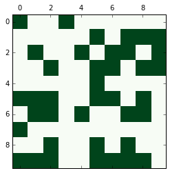

```python
import matplotlib.pyplot as plt
import random
import numpy as np
%matplotlib inline

wald2d = np.zeros([10, 10])

for it in range(10):
    for jt in range(10):
        wald2d[it][jt] = int(random.uniform(0, 2))

plt.matshow(wald2d, cmap = plt.cm.Greens)
```

Bisher berücksichtigen wir zur Darstellung unseres Waldes nur die Werte 0 und 1 (kein Baum, Baum). Wenn wir aber zum Beispiel auch Daten über die Größe oder die Dichte der Bäume in unserem Wald hätten, so könnten wir dies mit Werten zwischen 0 und 1 repräsentieren. Zur Darstellung müssen wir dank Farbverlauf sonst nichts an unserem Programm ändern.

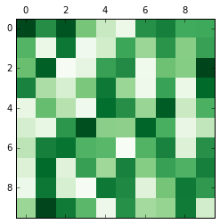

```python
import matplotlib.pyplot as plt
import random
import numpy as np
%matplotlib inline

wald2d=np.zeros([10, 10])

for it in range(10):
    for jt in range(10):
        wald2d[it][jt] = random.uniform(0, 1)

plt.matshow(wald2d, cmap = plt.cm.Greens)
```

In diesem Plot sehen wir nun dunklere und hellere Bereiche des Waldes. Anhand dieser Darstellung könnten wir uns überlegen, in welchen Bereichen es Sinn machen würde, Holz aus dem Wald zu entfernen. Praktisch wäre es, die besonderns dunklen Bereiche des Waldes durch Fällen von Bäumen zu lichten, damit dort wieder neue Bäume wachsen können.

Wie finden wir nun aber zuverlässig die dunklen Bereiche des Waldes? Einfach nur eine große Zahl in der Matrix zu suchen, reicht nicht aus: Damit könnte es sein, dass wir einen vereinzelten großen Baum fällen, der gar keine Nachbarn hat. Wir müssen also bei unserer Suche sicherstellen, dass auch auf den je benachbarten Bereichen große Bäume stehen.

Dazu müssen wir zuerst eine Grenze festlegen, ab der wir einen Baum als "groß" einstufen. In diesem Beispiel nehmen wir den Wert 0.75 an. Nachdem wir den Wald generiert haben, iterieren wir in einer weiteren Doppelschleife durch alle Positionen des Waldes und überprüfen, ob ein Baum an dieser Stelle "groß" ist. Sodann überprüfen wir zusätzlich alle vier Nachbarn an dieser Position. Steht an einem dieser Nachbarorte auch ein großer Baum, so wird der ursprüngliche, also der mittlere Baum gefällt.

In unserer Matrizendarstellung sind die vier Nachbarn des Baumes `wald2d[it][jt]`

- `wald2d[it+1][jt]`
- `wald2d[it-1][jt]`
- `wald2d[it][jt+1]`
- `wald2d[it][jt-1]`

Um nun den Wald vor und nach diesem Auslichten zu betrachten, erstellen wir zwei Plots. Wir verwenden dazu den Befehl `plt.show()`, der den Plot zeichnet, bevor das restliche Programm ausgeführt wird.

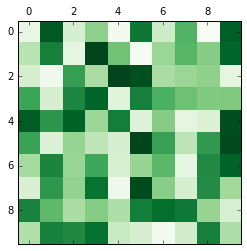

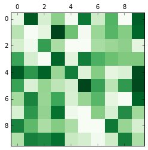

```python
import matplotlib.pyplot as plt
import random
import numpy as np
%matplotlib inline

wald2d = np.zeros([10, 10])

# Wald wir generiert
for it in range(10):
    for jt in range(10):
        wald2d[it][jt] = random.uniform(0, 1)

# erste Darstellung
plt.matshow(wald2d, cmap = plt.cm.Greens)
plt.show()

# Wald wird ausgelichtet
for it in range(1, 9):
    for jt in range(1, 9):
        if wald2d[it][jt] > 0.75:
            if wald2d[it+1][jt] > 0.75:
                wald2d[it][jt] = 0
            if wald2d[it-1][jt] > 0.75:
                wald2d[it][jt] = 0
            if wald2d[it][jt+1] > 0.75:
                wald2d[it][jt] = 0
            if wald2d[it][jt-1] > 0.75:
                wald2d[it][jt] = 0

# zweite Darstellung
plt.matshow(wald2d, cmap = plt.cm.Greens)
```

Um in diesen Plots zu sehen, wo genau die Bäume gefällt wurden, muss man sehr genau hinschauen. Lassen sich die Orte, an denen gefällt wurde, einfacher finden? Gesucht ist also eine Methode zur Darstellung des Unterschieds zwischen erstem und zweiten Plot.

Unterschiede sind mathematisch ausgedrückt Differenzen. Das Rechnen mit Matrizen bietet Vorteil, eine Matrix einfach von einer anderen subtrahieren zu können. Wir bauen diese Möglichkeit in das Programm ein und erstellen einen Plot der uns sagt, wo Bäume gefällt wurden.

Dazu müssen wir den zunächst generierten Wald unter einem eigenen Namen zwischenspeichern, damit wir Ihn beim Fällen nicht überschreiben.

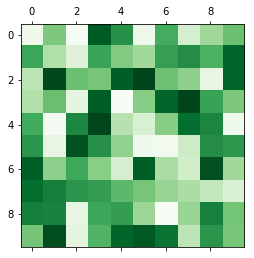

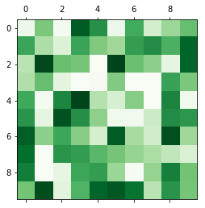

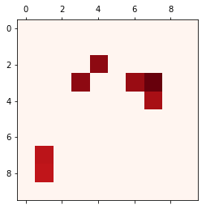

```python
import matplotlib.pyplot as plt
import random
import numpy as np
%matplotlib inline

wald2d = np.zeros([10, 10])
for it in range(10):
    for jt in range(10):
        wald2d[it][jt] = random.uniform(0, 1)

# erste Darstellung, der generierte Wald
plt.matshow(wald2d, cmap = plt.cm.Greens)
plt.show()

# Zwischenspeichern
wald2dalt = np.array(wald2d)

for it in range(1, 9):
    for jt in range(1, 9):
        if wald2d[it][jt] > 0.75:
            if wald2d[it+1][jt] > 0.75:
                wald2d[it][jt] = 0
            if wald2d[it-1][jt] > 0.75:
                wald2d[it][jt] = 0
            if wald2d[it][jt+1] > 0.75:
                wald2d[it][jt] = 0
            if wald2d[it][jt-1] > 0.75:
                wald2d[it][jt] = 0

# zweite Darstellung, der gelichtete Wald
plt.matshow(wald2d, cmap = plt.cm.Greens)

# dritte Darstellung, die Differenz, diesmal in Rot-Tönen
plt.matshow(wald2dalt - wald2d, cmap = plt.cm.Reds)
```

Wir könnten auch versuchen, den größten Baum im Wald zu finden. Dazu müssen wir wieder eine Doppelschleife verwenden, und somit alle Bäume abgehen. Wir merken uns immer die Größe des größten Baumes, dem wir bereits begegnet sind. Wenn der aktuelle Baum größer ist, wird diese Größe ersetzt.

```python
import matplotlib.pyplot as plt
import random
import numpy as np
%matplotlib inline

wald2d = np.zeros([10, 10])
for it in range(10):
    for jt in range(10):
        wald2d[it][jt] = random.uniform(0, 1)

maximum = 0
#Wir setzen den Wert für den größten Baum auf 0
#Somit wird der erste Baum garantiert größer sein un diesen Wert überschreiben


for it in range(10):
    for jt in range(10):
    # Diese Schleife läuft nun im Gegensatz zur vorherigen über alle Einträge, also auch die Ränder.
        if wald2d[it][jt] > maximum:
            maximum = wald2d[it][jt]

# Nach der Doppelschleife geben wir den finalen Wert des größten Baumes aus:

print("Größter Baum:")
print(maximum)
```

```
Größter Baum:
0.995210757744049
```

### Zusammenfassung

#### Vektoren

Vektoren sind so etwas wie Listen, deren Einträge in der Mathematik gewöhnlich übereinandergeschrieben werden. $\vec{v_1}= \left( \begin{array}{c} 1\\ 0\\ 0\\ 1\\ \end{array}\right)\ \ \ \ \ $

Durch Vektoren lässt sich genauso itierieren, wie durch Listen. Beachte, dass das erste Element (der erste Eintrag) in einem Vektor als 'nullter' Eintrag gezählt wird (`vektorname[0]`). Der zweite Eintrag hat somit die Bezeichnung `vektorname[1]`, usw.

#### Matrizen

Matrizen sind Vektoren von Vektoren, oder am Computer: Listen von Listen. $\vec{v_1}= \left( \begin{array}{c c c} 1&1&0&1\\ 0&1&0&0\\ 0&0&1&1\\ 1&1&0&0\\ \end{array}\right)$

Matrizen-Einträge werden mit `matrixname[0][0]`, `matrixname[0][1]`, .... `matrixname[n][m]` adressiert. Zum Iterieren durch eine Matrix kann eine Doppelschleife verwendet werden.

Auf Matrizen können eine Reihe von Grundrechenarten (Addieren, Subtrahieren, Multiplizieren ...) angewendet werden.

#### Random

Zum Erzeugen von Zufallszahlen kann das Python-Paket (bzw. Modul) `random` verwendet werden.

# Kapitel 9 - Functions

In diesem Kapitel werden wir das Recyclen von Rohstoffen betrachten und dabei etwas über Functions in Python lernen.

Nehmen wir an es gibt einen Produktionsprozess, der einen gewissen Rohstoff benötigt. Diesen Rohstoff kann man in einer Reinheit von 90% käuflich erwerben. Nach dem Produktionsprozess kann man den Rohstoff wiedergewinnen und theoretisch weiterbenutzen, er verliert aber ein Viertel seiner Reinheit. Mathematisch können wir das so ausdrücken:

```python
reinheit = 0.9
reinheit_neu = reinheit * 0.75
print(reinheit_neu)
```

```
0.675
```

Der Rohstoff hat nun also nur mehr eine Reinheit von 67.5%. Wenn wir ihn so weiter verwenden, würde er sehr schnell eine Reinheit haben, mit der der Prozess nicht mehr funktioniert. Was aber, wenn wir ihn mit neuem Rohstoff mischen?

```python
reinheit = 0.9
reinheit_rec = reinheit * 0.75

reinheit_neu = 0.5 * (reinheit + reinheit_rec) #Mittelwert
print(reinheit_neu)
```

```
0.7875000000000001
```

Nun hätten wir eine Reinheit von über 78% nach dem ersten Wiederverwenden. Interessant wäre nun herauszufinden, was passiert, wenn wir diese Schritte immer weiter wiederholen, also den Rohstoff immer wieder verwenden und neu mischen. Wie schnell fällt die Reinheit ab? Erreicht sie irgendwann 0?

Um das herauszufinden, können wir eine Liste und eine For-Schleife verwenden:

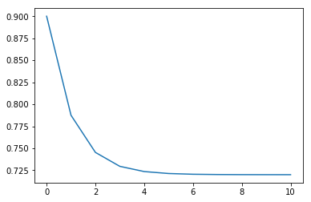

```python
import matplotlib.pyplot as plt
%matplotlib inline

reinheit = 0.9
reinheit_liste = [reinheit] #eine Liste mit einem Eintrag wird erstellt

for it in range(10):
    reinheit = 0.5 * (0.9 + reinheit * 0.75)
    reinheit_liste.append(reinheit)


plt.plot(reinheit_liste)
```

Es sieht so aus, also würde die Reinheit nie unter einen gewissen Wert fallen. Scheinbar bildet sich ein Gleichgewicht aus. Egal wie oft wir den Prozess wiederholen, wir kommen nicht unter 70 Prozent. Hat das etwas damit zu tun, dass der Prozess die Reinheit um 25% reduziert? Was hätte ein anderer Parameterwert für eine Auswirkung? Das könnten wir einfach überprüfen, indem wir einfach den Parameter von ändern, zum Beispiel auf 0.8:

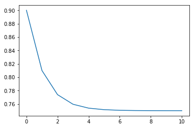

```python
import matplotlib.pyplot as plt
%matplotlib inline

reinheit = 0.9
reinheit_liste = [reinheit]

for it in range(10):
    reinheit = 0.5 * (0.9 + reinheit * 0.8)
    reinheit_liste.append(reinheit)


plt.plot(reinheit_liste)
```

Tatsächlich ändert sich der Fixpunkt. Wir wollen nun mehrere Parameterwerte in einem Plot vergleichen. Die einfachste Lösung wäre, die Forschleife oft zu kopieren und den Parameter jedes mal zu ändern. Wir könnten das Programm auch in eine For-Schleife legen, aber das Ändern des Parameters wird dadurch sehr umständlich. Glücklichweise gibt es eine bessere Lösung: Wir benutzen **Functions**.

### Functions

Functions (nicht zu verwechseln mit mathematischen Funktionen) sind Programmierstrukturen, die kompliziertere Prozesse automatisch ausführen. Ähnlich wie mathematische Funktionen können sie einen Input und einen Output haben. Wir können ihnen einen Namen geben und sie somit platzsparend und übersichtlich aufrufen.

Functions sind immer dann empfehlenswert, wenn man einen Prozess an unterschiedlichen Stellen im Code braucht. Functions werden in Python mit dem Wort **def** deklariert. Man schreibt `def namederfunction():`, die Function selbst wird dann eingerückt. Bauen wir nun unsere Recycling-Prozess in eine Function um.

```python
import matplotlib.pyplot as plt
%matplotlib inline


#eine eigene Function wird definiert:
def recyceln():
    reinheit = 0.9
    reinheit_liste = [reinheit]

    for it in range(10):
        reinheit = 0.5 * (0.9 + reinheit * 0.8)
        reinheit_liste.append(reinheit)


    plt.plot(reinheit_liste)
```

Man beachte: Nur durch das Definieren der Function wird sie noch nicht ausgeführt. Dazu müssen wir sie dezidiert aufrufen. Das macht man mit dem Namen der Funktion gefolgt von runden Klammern:

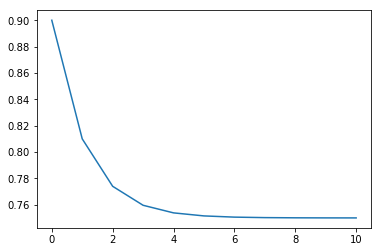

```python
import matplotlib.pyplot as plt
%matplotlib inline

def recyceln():
    reinheit = 0.9
    reinheit_liste = [reinheit]

    for it in range(10):
        reinheit = 0.5 * (0.9 + reinheit * 0.8)
        reinheit_liste.append(reinheit)


    plt.plot(reinheit_liste)

recyceln()
```

Was haben wir durch diese Function nun eigentlich gewonnen? Eine wichtige Eigenschaft von Functions ist, dass sie einen Inputwert haben können. Momentan verwendet unsere Function immer einen Parameter von 0.8, um zu berechnen wie viel Reinheit pro Schritt verloren wird. Diesen Parameter können wir umschreiben, sodass er als Inputparameter verwendet wird. Inputparameter werden wie folgt eingebaut:

Bei der **Definition** der Function kommt der **Name** des Parameters in die runde Klammer. Dieser Name kann dann innerhalb der Funktionsdefiniton benutzt werden.

Wenn die Function dann **aufgerufen** wird, gibt man den **Wert** den der Parameter haben soll, an.

Für unsere Recyclingfunction würde das also so aussehen:

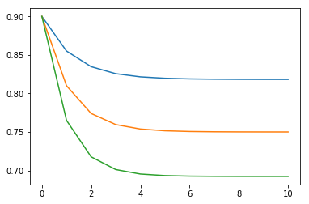

```python
import matplotlib.pyplot as plt
%matplotlib inline

def recyceln(verlustparameter):
    reinheit = 0.9
    reinheit_liste = [reinheit]

    for it in range(10):
        reinheit = 0.5 * (0.9 + reinheit * verlustparameter)
        reinheit_liste.append(reinheit)


    plt.plot(reinheit_liste)

recyceln(0.9)
recyceln(0.8)
recyceln(0.7)
```

Somit können wir sehr elegant verschiedene Verlustparameter miteinander vergleichen. Im Plot wäre es aber schön, wenn wir die Linien beschriften würden, damit wir wissen, welche Linie zu welchem Parameterwert gehört. Functions können wir einfach anpassen: Wenn wir in der Definition etwas ändern, ist diese Änderung für alle Aufrufe gültig.

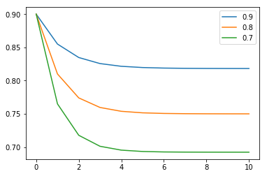

```python
import matplotlib.pyplot as plt
%matplotlib inline

def recyceln(verlustparameter):
    reinheit = 0.9
    reinheit_liste = [reinheit]

    for it in range(10):
        reinheit = 0.5 * (0.9 + reinheit * verlustparameter)
        reinheit_liste.append(reinheit)


    plt.plot(reinheit_liste, label = verlustparameter) #wir fügen eine Beschriftung hinzu
    plt.legend() #die Beschriftungen sollen in einer Legende angezeigt werden

recyceln(0.9)
recyceln(0.8)
recyceln(0.7)
```

Functions können wir auch beliebig ausbauen. Wir können zum Beispiel einen zweiten Inputparameter einbauen. Weitere Inputparameter werden einfach mit Beistrichen getrennt. Bauen wir nun auch den Parameter, der uns sagt wir rein die frische Resource ist, als Parameter ein.

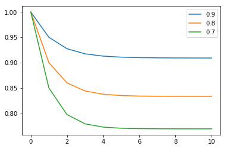

```python
import matplotlib.pyplot as plt
%matplotlib inline

def recyceln(verlustparameter, startreinheit):
    reinheit = startreinheit
    reinheit_liste = [reinheit]

    for it in range(10):
        reinheit = 0.5 * (startreinheit + reinheit * verlustparameter)
        reinheit_liste.append(reinheit)


    plt.plot(reinheit_liste, label = verlustparameter)
    plt.legend()

recyceln(0.9,1.0)
recyceln(0.8,1.0)
recyceln(0.7,1.0)
```

Zusätzlich zum Inputwert kann eine Function auch einen Outputwert haben. Das ist sozusagen das Ergebnis der Function, also das, was die Function an das Hauptprogramm zurückgeben soll. In unserem Fall wäre das zum Beispiel der letzte Reinheitswert unserer Zeitreihe. Der Outputwert wird mit dem Wort **return** am Ende der Definition festgelegt. Immer wenn wir eine weitere Function (zum Beispiel `print`) auf eine andere Function anwenden, wenden wir sie eigentlich auf den Outputwert an.

```
0.9091218642081055
0.8333508096
0.7692371351092773
```

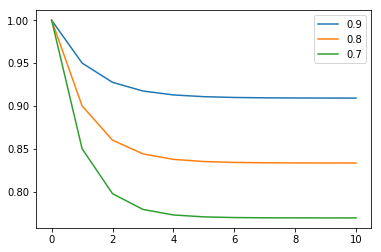

```python
import matplotlib.pyplot as plt
%matplotlib inline

def recyceln(verlustparameter, startreinheit):
    reinheit = startreinheit
    reinheit_liste = [reinheit]

    for it in range(10):
        reinheit = 0.5 * (startreinheit + reinheit * verlustparameter)
        reinheit_liste.append(reinheit)


    plt.plot(reinheit_liste, label = verlustparameter)
    plt.legend()

    return reinheit_liste[-1] #das Element -1 einer Liste ist das letzte Element der Liste, egal wie lang die Liste ist

print(recyceln(0.9,1.0))
print(recyceln(0.8,1.0))
print(recyceln(0.7,1.0))
```

Darüber hinaus ist es möglich Functions innerhalb von Functions zu verwenden. Wir können das Zusammenmischen der Rohstoffe in eine eigene Function auslagern:

```
0.9091218642081055
0.8333508096
0.7692371351092773
```

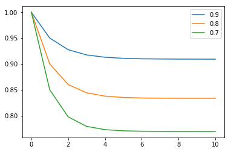

```python
import matplotlib.pyplot as plt
%matplotlib inline

def mischen(aktuell,start,verlust):
    neu = 0.5 * (start + aktuell * verlust)
    return neu


def recyceln(verlustparameter, startreinheit):
    reinheit = startreinheit
    reinheit_liste = [reinheit]

    for it in range(10):
        reinheit = mischen(reinheit,startreinheit,verlustparameter)
        reinheit_liste.append(reinheit)


    plt.plot(reinheit_liste, label = verlustparameter)
    plt.legend()

    return reinheit_liste[-1]

print(recyceln(0.9,1.0))
print(recyceln(0.8,1.0))
print(recyceln(0.7,1.0))
```

Analysieren wir nun einen anderen Recycle-Prozess. Wir produzieren Glasflaschen, die dann genutzt werden. Während der Nutzung lagern sich im Glas insgesamt 10 Milligram an Schadstoffen ab. Die Flaschen werden eingeschmolzen und neue Flaschen daraus gemacht. Dabei werden 15% der Schadstoffe entfernt. Wie lange dauert es, bis mehr als 50 Milligram in einer Flasche sind?

Versuchen wir dieses Problem mit Functions zu lösen. Schreiben wir zuerst eine Function, die den Verschmutzungsprozess beschreibt, und eine Function, die den Einschmelzprozess beschreibt.

Dann können wir diese Prozesse in eine For-Schleife geben und plotten was passiert.

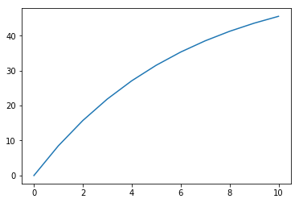

```python
import matplotlib.pyplot as plt
%matplotlib inline

def verschmutzen(startwert):
    return startwert + 10

def schmelzen(startwert):
    return startwert * 0.85

schadstoff = 0
schadstoff_liste = [schadstoff]

for it in range(10):
    schadstoff = verschmutzen(schadstoff)
    schadstoff = schmelzen(schadstoff)
    schadstoff_liste.append(schadstoff)

plt.plot(schadstoff_liste)
```

Wenn wir die Funktionen verschachteln wird es deutlich kompakter. Die Functions werden von innen nach außen abgearbeitet:

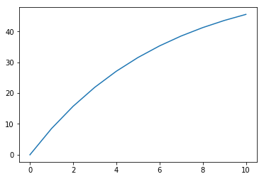

```python
import matplotlib.pyplot as plt
%matplotlib inline

def verschmutzen(startwert):
    return startwert + 10

def schmelzen(startwert):
    return startwert * 0.85

schadstoff = 0
schadstoff_liste = [schadstoff]

for it in range(10):
    schadstoff = schmelzen(verschmutzen(schadstoff))
    schadstoff_liste.append(schadstoff)

plt.plot(schadstoff_liste)
```

Wir sehen also: nach 10 Schritten ist der Grenzwert noch nicht überschritten. Wie können wir nun aber herausfinden, wann genau dieser Wert das erste mal überschritten wird? Wir könnten einfach die For-Schleife länger laufen lassen und so lange herumprobieren, bis wir einen geeigneten Wert finden. Es gibt aber eine bessere Lösung: Immer, wenn wir nicht wissen wie oft eine Schleife durchlaufen werden soll, sondern nur unter **welcher Bedingung sie abgebrochen werden sollte** (in unserem Fall beim Erreichen von 50 mg Schadstoff) kann man eine **While-Schleife** verwenden.

### Die While-Schleife

Bei der While-Schleife geben wir keine Anzahl an Schleifendurchgängen vor, sondern eine Bedingung. So lange diese Bedinung noch erfüllt ist wird die Schleife weiterlaufen. Man benutzt While-Schleifen mit

```
while bedingung:
   anweisungen
```

Für unser Beispiel also:

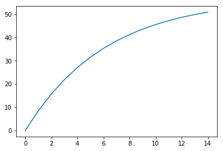

```python
import matplotlib.pyplot as plt
%matplotlib inline

def verschmutzen(startwert):
    return startwert + 10

def schmelzen(startwert):
    return startwert * 0.85

schadstoff = 0
schadstoff_liste = [schadstoff]

while schadstoff < 50:
    schadstoff = schmelzen(verschmutzen(schadstoff))
    schadstoff_liste.append(schadstoff)

plt.plot(schadstoff_liste)
```

While-Schleifen haben keine integrierte Variable, die mitzählt, wie oft die Schleife durchlaufen worden ist. Wenn wir so etwas brauchen (wie hier um die Anzahl der Wiederverwendungen zu finden) können wir das aber sehr einfach einbauen:

```
Nach
14
Prozessen ist der Schadstoffgrenzwert überschritten.
```

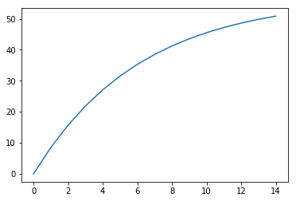

```python
import matplotlib.pyplot as plt
%matplotlib inline

def verschmutzen(startwert):
    return startwert + 10

def schmelzen(startwert):
    return startwert * 0.85

schadstoff = 0
schadstoff_liste = [schadstoff]
counter = 0

while schadstoff < 50:
    schadstoff = schmelzen(verschmutzen(schadstoff))
    schadstoff_liste.append(schadstoff)
    counter = counter + 1

plt.plot(schadstoff_liste)

print("Nach")
print(counter)
print("Prozessen ist der Schadstoffgrenzwert überschritten.")
```

**Vorsicht bei der Verweundung von While-Schleifen:** Wenn die Bedingung der While-Schleife schlecht gewählt wurde, kann es sein, dass sie für immer wahr bleibt. Dann läuft die While-Schleife unendlich lang weiter.

Man sollte While-Schleifen also nur dann verwenden, wenn wir ganz sicher sind, dass die Bedingung irgendwann einmal nicht mehr erfüllt sein wird. Wenn wir überhaupt nicht wissen, was mit unserem System passieren wird sollte man While-Schleifen vermeiden und eher auf For-Schleifen ausweichen.

## Zusammenfassung

### Functions

Mit Functions können wir Prozesse, die wir oft brauchen, einmalig definieren und dann oftmals wiederverwenden. Wir können sozusagen unsere eigenen Pythonbefehle zusammenbauen. Functions können **Inputwerte** haben, damit kann man sie anpassen. Außerdem gibt es **Outputwerte**, die wieder an das Hauptprogramm übergeben werden. Andere Variablen, die innerhalb der Function erstellt werden exisiteren nur innerhalb der Function und sind vom Hauptprogramm nicht aufrufbar.

Functions werden mit

```
def functionname(input1,input2,input3):
   Anweisungen
   return outputvariable
```

definiert.

### While-Schleifen

While-Schleifen werden, ähnlich wie For-Schleifen dazu benutzt Anweisung oftmals zu **wiederholen**. Bei der For-Schleife muss man angeben, wie oft sie durchlaufen werden muss. Die While-Schleife läuft im Gegensatz dazu so lange, bis eine **Bedingung**, die man wählen muss, **nicht mehr erfüllt** ist.

Somit ist das Verwenden der While-Schleife sehr **gefährlich**: Bleibt die Bedingung **immer erfüllt** (durch einen Denk- oder einen Programmierfehler) wird die Schleife niemals fertig und der Computer kann **abstürzen**, wenn man nicht schnell genug den Kernel beendet.

## Kapitel 10 - Rekursionen und Iterationen

Im letzten Kapitel haben wir **Functions** kennengelernt. Damit konnten wir eigene Befehle programmieren, die Input- und Outputwerte haben können.

Wir haben auch gesehen, dass eine Function auch eine andere Function aufrufen kann. Das könnte uns auf eine interessante Fragestellung bringen: Was passiert, wenn eine Function **sich selbst aufruft?** Kann das überhaupt funktionieren, oder bauen wir damit automatisch immer eine Endlosschleife?

Tatsächlich ist es möglich, dass wir Functions bauen, die sich selbst aufrufen. Streng genommen handelt es sich bei so etwas um eine **Rekursion**. Eine Rekursion tritt immer dann auf, wenn man eine Operation durchführt und dann die gleiche Operation auf den Output der ersten Operation anwendet und immer so weiter. Ähnlich wie bei While-Schleifen müssen wir aber aufpassen, dass wir keine Endlosschleifen produzieren. Functions, die garantiert sich selbst aufrufen werden immer Endlosschleifen produzieren. Functions die sich selbst nur unter einer gewissen Bedingung aufrufen sind für Rekursionen geeignet.

Versuchen wir nun eine solche Rekursion zu programmieren. Wir möchten eine Function haben, die einen **Countdown** herunterzählt, beginnend von einer beliebigen Zahl. Die Function soll also, wenn sie als Input 0 bekommt, die Zahl 0 ausgeben. Wenn Sie einen anderen Input bekommt, soll sie einerseits diesen Input ausgeben, andererseits auch sich selbst aufrufen. Der Input, mit dem sie sich selbst aufruft soll ihr eigener Input - 1 sein, sodass heruntergezählt wird.

```python
#wir definieren die Function countdown

def countdown(zahl):
    #in jedem fall möchten wir den input printen
    print(zahl)
    #wenn wir noch nicht bei 0 angekommen sind,
    #ruft die Funcstion sich selbst auf, aber
    #mit einem um 1 reduzierten Input.

    if zahl != 0: #wenn der input 0 ist
        countdown(zahl-1)


#nach der Definition müssen wir unsere Function auch aufrufen:
#den Input können wir frei wählen
countdown(10)
```

```
10
9
8
7
6
5
4
3
2
1
0
```

Unsere Countdownfunction scheint zu funktionieren. Sie zählt von einer beliebigen Zahl abwärts, indem sie sich immer wieder selbst aufruft. Wir benötigen also keine Schleife. Dennoch kann es passieren, dass wir eine **Endlosschleife** bauen, nämlich wenn wir nie auf den Input 0 kommen, weil wir die Function zum Beispiel mit einem anderen Input starten: (der Printbefehl wurde hier sicherheitshlaber auskommentiert)

```python
#wir definieren die Function countdown

def countdown(zahl):
    #in jedem fall möchten wir den input printen
    #print(zahl)
    #wenn wir noch nicht bei 0 angekommen sind,
    #ruft die Funcstion sich selbst auf, aber
    #mit einem um 1 reduzierten Input.

    if zahl != 0: #wenn der input 0 ist
        countdown(zahl-1)


#nach der Definition müssen wir unsere Function auch aufrufen:
#den Input können wir frei wählen
countdown(10.5)
```

```
---------------------------------------------------------------------------
RecursionError                            Traceback (most recent call last)
<ipython-input-5-9b03a94dcc7f> in <module>()
     14 #nach der Definition müssen wir unsere Function auch aufrufen:
     15 #den Input können wir frei wählen
---> 16 countdown(10.5)

<ipython-input-5-9b03a94dcc7f> in countdown(zahl)
      9
     10     if zahl != 0: #wenn der input 0 ist
---> 11         countdown(zahl-1)
     12
     13

... last 1 frames repeated, from the frame below ...

<ipython-input-5-9b03a94dcc7f> in countdown(zahl)
      9
     10     if zahl != 0: #wenn der input 0 ist
---> 11         countdown(zahl-1)
     12
     13

RecursionError: maximum recursion depth exceeded in comparison
```

Nach einiger Zeit liefert Python eine Fehlermeldung:

`RecursionError: maximum recursion depth exceeded`

Im Gegensatz zu While-Schleifen, sind Rekursionen in Python besser gesichert. Wenn es zu zu vielen Selbstaufrufen kommt, erkennt das Python als Endlosschleife und bricht die Berechnung ab, bevor der Computer einfriert.

Wenn wir nun zum Beispiel wissen wollen, welche die 20ste Zahl in dieser Folge ist, könnten wir eine Schleife bauen, die 20 Fibonacci-Zahlen ausrechnet. Eleganter geht das mit einer Rekursion: Dazu müssen wir nur folgende drei Dinge wissen.

- Die erste Fibonaccizahl ist 0.
- Die zweite Fibonaccizahl ist 1.
- Die $n$-te Fibonccizahl kann man ausrechnen, indem man die $(n-1)$-te zur $(n-2)$-ten addiert.

Als Rekursion geschrieben:

```python
def fibonacci(n):
    ret = 0 #wir legen eine Variable an, die wir auf 0 setzen

    #wir kennen die erste Fibonaccizahl
    if n == 0:
        ret = 0

    #wir kennen die zweite Fibonaccizahl
    if n == 1:
        ret = 1

    #alle anderen können wir rekursiv ausrechnen
    if n > 1:
        ret = fibonacci(n-1) + fibonacci(n-2)

    return ret

fibonacci(20)
```

```
6765
```

Dank der Rekursion benötigen wir keine Schleife, keine Liste und keine Variablen die uns alte Fibonacci-Zahlen speichern.

Auf ähnlich Weise können wir auch kompliziertere Zahlenmengen finden. Besonders spanned ist zum Beispiel die **Mandelbrot-Menge**. Um zu verstehen, was die Mandelbrotmenge genau ist, müssen wir uns zuerst mit der **Mandelbrot-Folge** auseinandersetzen. Die Mandelbrot-Folge für die Zahl c wird wie folgt berechnet:

$$z_{n+1} = z_n^2 + c$$

Ähnlich wie bei der Fibonaccifolge brauchen wir also das $n$-te Element um das $n+1$ste zu errechnen.

Die Mandelbrot-Menge ist nun die Menge aller Zahlen, bei denen keines der Elemente dieser Reihe größer wird als 2.

Für reelle Zahlen können wir uns diese Folge noch im Kopf ausrechnen:

- Für c = 0

$$0^2 + 0 = 0,\ \ \ \ 0^2 + 0 = 0,\ \ \ \ 0^2 + 0 = 0,\ \ \ \ ...$$

- Für c = -1

$$-1^2 - 1 = 0,\ \ \ \ 0^2 - 1 = -1,\ \ \ \ -1^2 - 1 = 0,\ \ \ \ ...$$

c = 1 ist also nicht in der Mandebrot-Menge, denn die Elemente der Reihe werden unendlich groß.

c = 0 ist in der Mandelbrot-Menge, denn die Elemente sind alle 0.

c = -1 ist in der Mandelbrot-Menge, denn die Elemente sind immer abwechseln 0 und -1.

Was ist nun aber mit den Zahlen dazwischen? Und mit komplexen Zahlen? Das wird im Kopf sehr aufwendig, weswegen wir ein Programm schreiben, das die Arbeit für uns erledigt.

Zuerst brauchen wir eine **Doppelschleife**, die uns über einen interessanten Bereich der **komplexen Ebene wandert**. Später soll für jede Zahl die vorkommt bestimmt werden, ob Sie in der Mandelbrot-Menge ist oder nicht. Fürs erste begnügen wir uns damit einfach den Absolutbetrag der Zahl darzustellen. In Python kann man komplexe Zahlen mit `complex(realteil,imaginärteil)` definieren und den Absolutbetrag mit `abs` berechnen.

Wir untersuchen komplexe Zahlen mit einem Realteil zwischen -2 und 0.5 und einem Imaginärteil zwischen -1.25 und 1.25. Wir hätten gern eine Genauigkeit von 0.01. Um **Zahlen aus diesen Intervallen** zu erstellen ist der `range` Befehl unzureichend. Wir benötigen den Befehl `np.arange` mit dem man Startwert, Endwert und Schrittweite angeben kann.

```
Text(0.5,0,'Realteil')
```

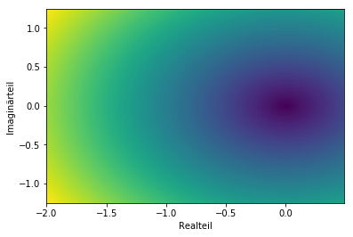

```python
import matplotlib.pyplot as plt
%matplotlib inline

import numpy as np

#wir definieren den Realteil der Zahlen, die wir untersuchen wollen:
r_bereich = np.arange(-2,0.5,0.01)
#und den Imaginärteil der Zahlen, die wir untersuchen wollen.
i_bereich = np.arange(-1.25,1.25,0.01)

#Wir legen eine Matrix in der richtigen Größe an, die mit 0en gefüllt ist.
mandelbrot = np.zeros([len(i_bereich),len(r_bereich)])


#mit einer doppelschleifen gehen wir über alle Zahlen
for it in range(len(i_bereich)):
    for jt in range(len(r_bereich)):
        #und speichern den absolutbetrag der Zahl in die Matrix
        mandelbrot[it,jt]= abs(complex(r_bereich[jt],i_bereich[it]))

plt.pcolormesh(r_bereich,i_bereich,mandelbrot)
#der Befehl pcolormesh funktioniert ähnlich wie imshow,
#nur können wir hier x und y Intervalle für die Beschriftung übergeben

plt.ylabel("Imaginärteil")
plt.xlabel("Realteil")
```

Nun steht also das **Grundgerüst** unseres Programms. Wir wandern über einen Bereich der komplexen Ebene und zeichnen das Ergebnis einer Operation. Momentan ist die Operation einfach der Absolutbetrag der Zahl. Wir werden Sie im nächsen Schritt aber durch eine andere Information ersetzen: Nämlich wie viele Schritte es braucht, bis ein Element der Mandelbrotfolge größer als 2 wird.

Dazu müssen wir zuerst eine **Function** bauen, die uns die **Mandelbrotfolge ausrechnet**. Auch hier beitet sich eine Rekursion an. Wenn wir das $n$-te Element der Mandelbrotfolge der Zahl $c$ haben wollen, können wir das einfach berechnen, indem wir das $(n-1)$-te Element quadrieren und $+\ c$ rechnen. Das "nullte" Element der Mandelbrotfolge ist immer die Zahl $c$ selbst.

Mathematisch ausgedrückt:

$$M_0 = c $$ $$M_n = \left(M_{n-1}\right)^2 + c $$

Das können wir als Function wie folgt schreiben:

```python
def mandelbrotelement(c, it):
    # das nullte element ist die Zahl selbst
    if it == 0:
        return c
    else:
    #sonst müssen wir es aus dem vorherigen Element ausrechnen
        return mandelbrotelement(c, it - 1) ** 2  + c

mandelbrotelement(complex(-1,0),10)
```

```
(-1+0j)
```

Unsere Rekursion scheint zu funktionieren. Das 10te Element der Mandelbrotreihe der Zahl `-1` ist wieder `-1`. Mit dieser Function können wir eine weitere Function schreiben, die uns die ersten 50 Elemente der Mandelbrotreihe ausrechnet:

```python
def mandelbrotfolge(c):
    ret = [] # wir erstellen eine leere Liste
    for it in range(50):
        #wir füllen diese Liste mit den Elementen der Mandelbrotfolge
        z=mandelbrotelement(c,it)
        ret.append(z)
    return ret

def mandelbrotelement(c, it):
    if it == 0:
        return c
    else:
        return mandelbrotelement(c, it - 1) ** 2  + c


mandelbrotfolge(complex(0.1,0.1))
```

```
[(0.1+0.1j),
 (0.1+0.12000000000000001j),
 (0.0956+0.12400000000000001j),
 (0.09376336+0.12370880000000001j),
 (0.09348770048104961+0.123198705499136j),
 (0.0935620291045716+0.12303512735871254j),
 (0.09361621072599009+0.12302283233364109j),
 (0.09362937763530182+0.12303386279170858j),
 (0.093629128962925+0.1230391680025096j),
 (0.09362777692760627+0.12304010025679593j),
 (0.0936272943412032+0.1230399421199872j),
 (0.0936272428887645+0.1230397937531853j),
 (0.09362726976412533+0.12303975330942594j),
 (0.0936272847490399+0.12303975234962611j),
 (0.09362728779122048+0.1230397558573796j),
 (0.09362728749769646+0.12303975726284078j),
 (0.09362728709687754+0.12303975745378956j),
 (0.09362728697483377+0.12303975739091227j),
 (0.09362728696745333+0.12303975734910574j),
 (0.09362728697635904+0.1230397573394611j),
 (0.09362728698040003+0.12303975733984661j),
 (0.09362728698106185+0.1230397573409132j),
 (0.09362728698092332+0.12303975734127579j),
 (0.09362728698080815+0.12303975734130959j),
 (0.09362728698077827+0.12303975734128758j),
 (0.09362728698077809+0.12303975734127612j),
 (0.09362728698078088+0.12303975734127393j),
 (0.09362728698078193+0.1230397573412742j),
 (0.09362728698078207+0.12303975734127451j),
 (0.09362728698078202+0.12303975734127459j),
 (0.09362728698078199+0.12303975734127459j),
 (0.09362728698078197+0.12303975734127459j),
 (0.09362728698078197+0.12303975734127459j),
 (0.09362728698078197+0.12303975734127459j),
 (0.09362728698078197+0.12303975734127459j),
 (0.09362728698078197+0.12303975734127459j),
 (0.09362728698078197+0.12303975734127459j),
 (0.09362728698078197+0.12303975734127459j),
 (0.09362728698078197+0.12303975734127459j),
 (0.09362728698078197+0.12303975734127459j),
 (0.09362728698078197+0.12303975734127459j),
 (0.09362728698078197+0.12303975734127459j),
 (0.09362728698078197+0.12303975734127459j),
 (0.09362728698078197+0.12303975734127459j),
 (0.09362728698078197+0.12303975734127459j),
 (0.09362728698078197+0.12303975734127459j),
 (0.09362728698078197+0.12303975734127459j),
 (0.09362728698078197+0.12303975734127459j),
 (0.09362728698078197+0.12303975734127459j),
 (0.09362728698078197+0.12303975734127459j)]
```

Solche Functions, die sich selbst rekursiv aufrufen, sehen zwar sehr elegant aus, haben in der Praxis aber meist einige Nachteile. Somit ist es für viele Anwendung, vor allem in Python, sinnvoll, dass wir die Rekursion nicht durch rekursives Aufrufen einer Funktion, sondern durch eine Iteration durchführen. Wir starten also nicht beim letzten Element und arbeiten uns vor zum Element 0, sondern wir starten am Anfang und iterieren so lange, bis wir bei dem Element sind, das uns interessiert. Der gleiche Rekursive Prozess wie oben, jetzt als Iteration ausgedrückt:

```python
def mandelbrotfolge(c):
    ret = [c]
    for it in range(1,50):
        z = ret[it - 1]**2 + c
        ret.append(z)
    return ret

mandelbrotfolge(complex(0.1,0.1))
```

```
[(0.1+0.1j),
 (0.1+0.12000000000000001j),
 (0.0956+0.12400000000000001j),
 (0.09376336+0.12370880000000001j),
 (0.09348770048104961+0.123198705499136j),
 (0.0935620291045716+0.12303512735871254j),
 (0.09361621072599009+0.12302283233364109j),
 (0.09362937763530182+0.12303386279170858j),
 (0.093629128962925+0.1230391680025096j),
 (0.09362777692760627+0.12304010025679593j),
 (0.0936272943412032+0.1230399421199872j),
 (0.0936272428887645+0.1230397937531853j),
 (0.09362726976412533+0.12303975330942594j),
 (0.0936272847490399+0.12303975234962611j),
 (0.09362728779122048+0.1230397558573796j),
 (0.09362728749769646+0.12303975726284078j),
 (0.09362728709687754+0.12303975745378956j),
 (0.09362728697483377+0.12303975739091227j),
 (0.09362728696745333+0.12303975734910574j),
 (0.09362728697635904+0.1230397573394611j),
 (0.09362728698040003+0.12303975733984661j),
 (0.09362728698106185+0.1230397573409132j),
 (0.09362728698092332+0.12303975734127579j),
 (0.09362728698080815+0.12303975734130959j),
 (0.09362728698077827+0.12303975734128758j),
 (0.09362728698077809+0.12303975734127612j),
 (0.09362728698078088+0.12303975734127393j),
 (0.09362728698078193+0.1230397573412742j),
 (0.09362728698078207+0.12303975734127451j),
 (0.09362728698078202+0.12303975734127459j),
 (0.09362728698078199+0.12303975734127459j),
 (0.09362728698078197+0.12303975734127459j),
 (0.09362728698078197+0.12303975734127459j),
 (0.09362728698078197+0.12303975734127459j),
 (0.09362728698078197+0.12303975734127459j),
 (0.09362728698078197+0.12303975734127459j),
 (0.09362728698078197+0.12303975734127459j),
 (0.09362728698078197+0.12303975734127459j),
 (0.09362728698078197+0.12303975734127459j),
 (0.09362728698078197+0.12303975734127459j),
 (0.09362728698078197+0.12303975734127459j),
 (0.09362728698078197+0.12303975734127459j),
 (0.09362728698078197+0.12303975734127459j),
 (0.09362728698078197+0.12303975734127459j),
 (0.09362728698078197+0.12303975734127459j),
 (0.09362728698078197+0.12303975734127459j),
 (0.09362728698078197+0.12303975734127459j),
 (0.09362728698078197+0.12303975734127459j),
 (0.09362728698078197+0.12303975734127459j),
 (0.09362728698078197+0.12303975734127459j)]
```

Wir sind aber eigentlich nicht an der gesamten Folge interessiert, sondern nur an den Elementen vor dem ersten Element das größer ist als 2. Somit müssen wir für viele Zahlen garnicht die ganze For-Schleife durchlaufen: Immer wenn wir eine Zahl finden, die größer ist als 2 könnten wir die Schleife eigentlich abbrechen, um Rechenzeit zu sparen. Wie **unterbrechen** wir aber eine Schleife, die eigentlich bis 50 läuft schon vorzeitig?

Dafür gibt es in Python den Befehl `break`. `break` benutzt man innerhalb von Schleifen, um die Schleife **vorzeitig abzubrechen**. Brechen wir unsere Schleife nun ab, sobald wir ein Element ausrechnen, das größer ist als 2:

```python
def mandelbrotfolge(c):
    ret = [c]
    for it in range(1,50):
        z = ret[it - 1]**2 + c
        ret.append(z)
        if abs(z)>2:
            break
    return ret

mandelbrotfolge(complex(0.5,0.5))
```

```
[(0.5+0.5j), (0.5+1j), (-0.25+1.5j), (-1.6875-0.25j), (3.28515625+1.34375j)]
```

Das ist eigentlich schon alles, was wir zum Zeichnen der Mandelbrotmenge benötigen. Für jede Zahl, die wir untersuchen, schauen wir die Mandelbrotfolge an. Da wir automatisch abbrechen, sobald eine Zahl zu groß ist, ist die **Länge der Liste**, die unsere Funkcion zurückgibt, automatisch die Anzahl der Zahlen in der Folge, die kleiner sind als 2. Für Zahlen, die Teil der Mandelbrotmenge sind liefert unsere Function also die volle Länge von 50.

Schreiben wir also eine Function, die die Länge der Liste liefert. Diese Function bauen wir dann in unser **ursprüngliches Gerüst** ein, um die komplexe Zahlenebene nach Zahlen die Teil der Mandelbrotmenge sind, zu untersuchen. Die Form die entsteht ist erstaunlich.

```
Text(0.5,0,'Realteil')
```

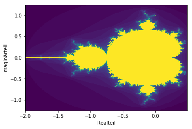

```python
import matplotlib.pyplot as plt
%matplotlib inline

import numpy as np


def mandelbrotfolge(c):
    ret = [c]
    for it in range(1,50):
        z = ret[it - 1]**2 + c
        ret.append(z)
        if abs(z)>2:
            break
    return ret



def check_mandelbrot(c):
    #gibt die Länge der Liste zurück
    return len(mandelbrotfolge(c))


r_bereich = np.arange(-2,0.5,0.01)
i_bereich = np.arange(-1.25,1.25,0.01)


mandelbrot = np.zeros([len(i_bereich),len(r_bereich)])

for it in range(len(i_bereich)):
    for jt in range(len(r_bereich)):
        mandelbrot[it,jt]= check_mandelbrot(complex(r_bereich[jt],i_bereich[it]))

plt.pcolormesh(r_bereich,i_bereich,mandelbrot)
plt.ylabel("Imaginärteil")
plt.xlabel("Realteil")
```

Wir können auch hineinzoomen und uns einen winzigen Teil der komplexen Ebene ansehen. Egal wie sehr wir hineinzoomen, wir werden immer feinere Strukturen erkennen.

```
Text(0.5,0,'Realteil')
```

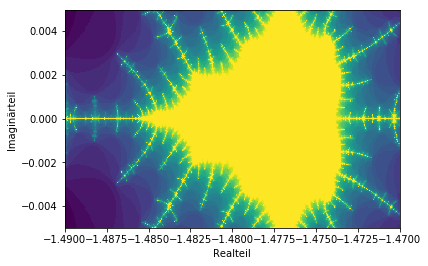

```python
import matplotlib.pyplot as plt
%matplotlib inline

import numpy as np


def mandelbrotfolge(c):
    ret = [c]
    for it in range(1,50):
        z = ret[it - 1]**2 + c
        ret.append(z)
        if abs(z)>2:
            break
    return ret



def check_mandelbrot(c):

    return len(mandelbrotfolge(c))


r_bereich = np.arange(-1.49,-1.47,0.00005)
i_bereich = np.arange(-0.005,0.005,0.00005)


mandelbrot = np.zeros([len(i_bereich),len(r_bereich)])

for it in range(len(i_bereich)):
    for jt in range(len(r_bereich)):
        mandelbrot[it,jt]= check_mandelbrot(complex(r_bereich[jt],i_bereich[it]))

plt.pcolormesh(r_bereich,i_bereich,mandelbrot)
plt.ylabel("Imaginärteil")
plt.xlabel("Realteil")
```

```
Text(0.5,0,'Realteil')
```

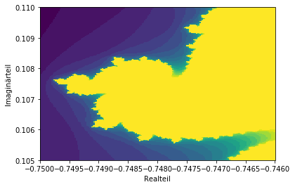

```python
import matplotlib.pyplot as plt
%matplotlib inline

import numpy as np


def mandelbrotfolge(c):
    ret = [c]
    for it in range(1,50):
        z = ret[it - 1]**2 + c
        ret.append(z)
        if abs(z)>2:
            break
    return ret



def check_mandelbrot(c):

    return len(mandelbrotfolge(c))


r_bereich = np.arange(-0.75,-0.746,0.00002)
i_bereich = np.arange(0.105,0.11,0.00002)


mandelbrot = np.zeros([len(i_bereich),len(r_bereich)])

for it in range(len(i_bereich)):
    for jt in range(len(r_bereich)):
        mandelbrot[it,jt]= check_mandelbrot(complex(r_bereich[jt],i_bereich[it]))

plt.pcolormesh(r_bereich,i_bereich,mandelbrot)
plt.ylabel("Imaginärteil")
plt.xlabel("Realteil")
```

Warum die Mandelbrotmenge genau diese fraktale Form hat, kann nicht erklärt werden. Sie dient aber als eindrucksvolles Beispiel, dass sehr simple Rekursionen zu außerordentlicher Komplexität führen können und die Komplexität nicht durch den Menschen entsteht, sondern von Natur aus vorhanden ist, und nur entdeckt werden muss.

## Zusammenfassung

### Rekursionen

Von Rekursionen spricht man, wenn man eine Function **in sich selbst einsetzt**. Dabei muss man aber, ähnlich wie bei While-Schleifen aufpassen, dass man **keine Endlosschleifen** produziert. Dafür ist es wichtig, dass es zumindest eine Bedingung gibt, bei der die Function sich selbst nicht aufruft, und diese Bedingung auch garantiert irgendwann erreicht wird. Meist ist es jedoch besser, dass man rekursive Aufrufe vermeidet, und die Rekursion auf eine Iteration umschreibt.

### Komplexe Zahlen

Komplexe Zahlen können in Python mit `complex(Realteil, Imaginärteil)` eingegeben werden. Dann können die **normalen Rechenoperationen** verwendet werden (+,*,abs(),...) und Pyhton geht korrekt mit komplexen Zahlen um. Anstelle vom in der Mathematik üblichen $i$, verwendet Python beim Ausgeben von komplexen Zahlen das eher in der Technik verbreitete $j$ für die imaginäre Einheit $\sqrt{-1}$.

### np.arange

Mit `np.arange` kann man **Zahlenintervall von beliebeiger Genauigkeit** erstellen, über die man dann iterieren kann. Die Syntax dazu lautet `np.arange(startwert, zielwert, schrittweite)`.

### break

Oft möchte man Schleifen **vorzeitig unterbrechen**, obwohl die primäre Abbruchbedingung noch nicht erreicht ist. Dazu gibt es in Python den Befehl `break`. `break` unterbricht die aktuelle Schleife und der Code direkt unterhalb der Schleife wird ganz normal weiter ausgeführt.

# Kapitel 11 - Klassen und Objekte

Modernes Programmieren ist zumeist objektorientiert. Das heißt der Fokus liegt nicht so sehr auf fest vorgelegten Abläufen und Rechenoperationen, die abgearbeitet werden, sondern auf Objekten, die definiert werden, Eigenschaften und Fähigkeit haben und sehr vielseitig benutzt werden können.

Auch in Python kann man sehr leicht eigene **Objekte** erstellen. Ein Objekt gehört immer einer **Klasse** an, die man auch selbst definieren kann.

Im Folgenden werden wir Objekte und Klassen nutzen um ein Verkehrssystem zu simulieren.

Dieses Verkehrssystem wird sehr rudimentär sein. Es wird Personen geben, die einen Heimatort und einen Arbeitsort besitzen, und zwischen diesen Orten hin- und herpendeln. Eine Person wird immer ein Objekt einer Klasse sein und Eigenschaften (z.B. Heimatort) und Fähigkeiten - beim Programmieren eher **Methoden** genannt - (z.b. zur Arbeit fahren) haben.

Wir erstellen nun also die Klasse `Person` und legen die Initialisierungsmethode fest. Dort bekommen die Personen eine zufällige Heimatadresse. **Methoden werden ähnlich definiert wie Functions**, der einzige Unterschied ist, dass Methoden als erste Inputvariable immer `self` haben, also sich selbst. Immer wenn also eine Methode aufgerufen wird, wird automatisch übergeben, welches Objekt dieser Klasse (also für uns welche Person) die Methode aufgerufen hat.

```python
import matplotlib.pyplot as plt
%matplotlib inline
import random


class Person:
    def __init__(self):
        #eine neue Person wird initialisiert

        #sie bekommt eine zufällig Heimadresse
        self.home = [random.randint(0,10),random.randint(0,10)]
```

Wie beim Definieren von Funktion, macht das Definieren von Klassen an sich noch nichts. Sie müssen immer erst im Hauptprogramm aufgerufen werden. Erstellen wir nun zur Probe eine Person und zeichen wir ihre Heimatadresse als Scatterplot.

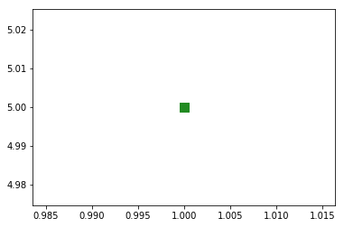

```python
import matplotlib.pyplot as plt
%matplotlib inline
import random


class Person:
    def __init__(self):
        #eine neue Person wird initialisiert

        #sie bekommt eine zufällig Heimadresse
        self.home = [random.randint(0,10),random.randint(0,10)]


#----Hier startet das Hauptprogramm----


#wir erstellen ein Objekt der Klasse person mit dem Namen person1
person1 = Person()
#Dann zeichnen wir den Heimatort von person1
#s ist die Größe des Markers, die Form "s" steht für square
plt.scatter(person1.home[0],person1.home[1], s = 100, marker = "s", c = "forestgreen")
```

Wir haben nun erfolgreich ein Objekt der Klasse `Person` erstellt und die Heimatadresse gezeichnet. Eleganter wäre das aber, wenn wir das Zeichnen nicht im Hauptprogramm machen, sondern es als **Methode** erstellen: Alle Personen sollen die Fähigkeit erhalten sich selbst zu zeichnen. Wir nennen diese Methode `zeichnen` und definieren sie direkt nach `__init__`. Immer wenn wir diese Methode dann aufrufen möchten schreiben wir `NameDerPerson.zeichnen()`.

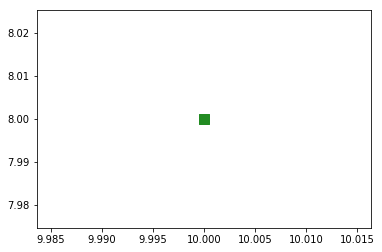

```python
import matplotlib.pyplot as plt
%matplotlib inline
import random


class Person:
    def __init__(self):
        #eine neue Person wird initialisiert

        #sie bekommt eine zufällig Heimadresse
        self.home = [random.randint(0,10),random.randint(0,10)]

    def zeichnen(self):
        #Die Personen zeichnen ihre Heimatadresse
        #s ist die Größe des Markers, die Form "s" steht für square
        plt.scatter(self.home[0],self.home[1], s = 100, marker = "s", c = "forestgreen")


#----Hier startet das Hauptprogramm----

#wir erstellen ein Objekt der Klasse person mit dem Namen person1
person1 = Person()
#Dann zeichnen wir den Heimatort von person1
person1.zeichnen()
```

Mit dieser eleganten Lösung können wir nun auch **mehrere Objekte** der gleichen Klasse einfach erstellen und verwalten. Wir erstellen eine leere Liste und fügen dann 20 Objekte der Klasse `Person` hinzu. In einer Schleife rufen wir sie dann alle auf und lassen sie zeichnen.

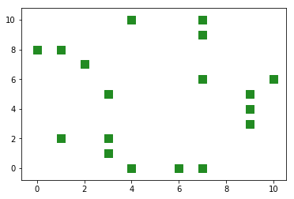

```python
import matplotlib.pyplot as plt
%matplotlib inline
import random


class Person:
    def __init__(self):
        #eine neue Person wird initialisiert

        #sie bekommt eine zufällig Heimadresse
        self.home = [random.randint(0,10),random.randint(0,10)]

    def zeichnen(self):
        #Die Personen zeichnen ihre Heimatadresse
        #s ist die Größe des Markers, die Form "s" steht für square
        plt.scatter(self.home[0],self.home[1], s = 100, marker = "s", c = "forestgreen")


#----Hier startet das Hauptprogramm----

#Wir erstellen eine leere Liste
allepersonen=[]

#Wir fügen neue Personen
for it in range(20):
    allepersonen.append(Person())

for it in range(20):
    allepersonen[it].zeichnen()
```

Die letzte Schleife läuft hierbei über eine Liste von Objekten und ruft im it-ten Schritt das it-te Objekt auf um etwas damit zu machen. Diese Struktur ist so häufig, dass es in Python dafür eine **Kurzschreibweise** gibt. Statt

`for it in range(20):`

$\ \ \ \ \ \ $`Befehl für Objekt das unter listenname[it] gespeichert ist`

kann man verkürz schreiben

`for obj in listenname:`

$\ \ \ \ \ \ $`Befehl für obj`

, wobei `obj` eine frei wählbare Bezeichnung ist.

Für unser Programm wäre diese Kurzschreibweise also:

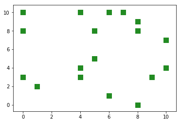

```python
import matplotlib.pyplot as plt
%matplotlib inline
import random


class Person:
    def __init__(self):
        #eine neue Person wird initialisiert

        #sie bekommt eine zufällig Heimadresse
        self.home = [random.randint(0,10),random.randint(0,10)]

    def zeichnen(self):
        #Die Personen zeichnen ihre Heimatadresse
        #s ist die Größe des Markers, die Form "s" steht für square
        plt.scatter(self.home[0],self.home[1], s = 100, marker = "s", c = "forestgreen")


#----Hier startet das Hauptprogramm----

#Wir erstellen eine leere Liste
allepersonen=[]

#Wir fügen neue Personen
for it in range(20):
    allepersonen.append(Person())

for p in allepersonen:
    p.zeichnen()
```

Zusätzlich zu einer Heimatadresse bekommen alle Personen nun auch einen **Arbeitsort**. In unserem Modell gibt es 3 Arbeitsorte, die unterschiedlich groß sind. Ein Arbeitsort befindet sich auf Position [7,9], einer auf [4,1] und einer auf [5,5].

Beim Intitialisieren bekommen alle Personen also auch einen Arbeitsort aus einer Liste der Arbeitsorte zugewiesen. Da nicht alle Arbeitsorte gleich oft besucht werden, kommen auch nicht alle Orte gleich oft in der Liste vor.

Auch in der Methode `zeichnen` nehmen wir eine Änderung vor: Auch der Arbeitsplatz soll gezeichnet werden.

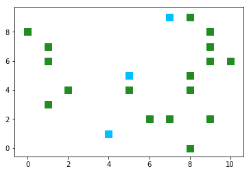

```python
import matplotlib.pyplot as plt
%matplotlib inline
import random


class Person:
    def __init__(self):
        #eine neue Person wird initialisiert

        #sie bekommt eine zufällig Heimadresse
        self.home = [random.randint(0,10),random.randint(0,10)]
        #und eine Arbeitsadresse aus einer Liste
        self.work = random.choice([[5,5],[5,5],[5,5],[4,1],[4,1],[7,9]])

    def zeichnen(self):
        #Die Personen zeichnen ihre Heimatadresse
        #s ist die Größe des Markers, die Form "s" steht für square
        plt.scatter(self.home[0],self.home[1], s = 100, marker = "s", c = "forestgreen")
        #Und ihren Arbeitsort
        plt.scatter(self.work[0],self.work[1], s = 100, marker = "s", c = "deepskyblue")


#----Hier startet das Hauptprogramm----

#Wir erstellen eine leere Liste
allepersonen=[]

#Wir fügen neue Personen
for it in range(20):
    allepersonen.append(Person())

for p in allepersonen:
    p.zeichnen()
```

Nun möchten wir noch eine wichtige Methode in unser Verkehrssystem einbauen. Personen sollen die Fähigkeit bekommen von ihrem **Heimatort zum Arbeitsort zu fahren**. Damit sehen wir dann, welche Straßen der Modellstadt häufig benutzt werden und welche nicht so häufig.

Für das Fahren benutzen wir die sogenannte **Manhattan-Metrik**: In dieser Metrik ist es nur erlaubt entlang der x-Achse und entlang der y-Achse zu fahren, nicht aber diagonal. Unsere Personen fahren also zuerst in x-Richtung bei konstantem y, dann in y-Richtung bei konstantem x.

Das Fahren selbst implementieren wir einfach als Linienplots zusätzlich zu unserem bisherigen Plot.

Erstellen wir nun die Methode `fahren` und rufen wir sie für alle Personen auf.

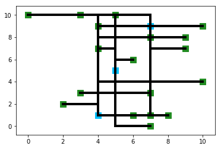

```python
import matplotlib.pyplot as plt
%matplotlib inline
import random


class Person:
    def __init__(self):
        #eine neue Person wird initialisiert

        #sie bekommt eine zufällig Heimadresse
        self.home = [random.randint(0,10),random.randint(0,10)]
        #und eine Arbeitsadresse aus einer Liste
        self.work = random.choice([[5,5],[5,5],[5,5],[4,1],[4,1],[7,9]])

    def zeichnen(self):
        #Die Personen zeichnen ihre Heimatadresse
        #s ist die Größe des Markers, die Form "s" steht für square
        plt.scatter(self.home[0],self.home[1], s = 100, marker = "s", c = "forestgreen")
        #Und ihren Arbeitsort
        plt.scatter(self.work[0],self.work[1], s = 100, marker = "s", c = "deepskyblue")

    def fahren(self):
        #Wir zeichnen zwei Linien:
        #Linie 1 geht in der x-Richtung von home nach work, y bleibt konstant bei home
        #Linie 2 geht in y-Richtung von home nach work, x bleibt konstant bei work
        plt.plot([self.home[0],self.work[0]],[self.home[1],self.home[1]],c = "black", lw = 4)
        plt.plot([self.work[0],self.work[0]],[self.home[1],self.work[1]],c = "black", lw = 4)


#----Hier startet das Hauptprogramm----

#Wir erstellen eine leere Liste
allepersonen=[]

#Wir fügen neue Personen
for it in range(20):
    allepersonen.append(Person())

for p in allepersonen:
    p.zeichnen()
    p.fahren()
```

Nun sehen wir welche Strecken benutzt werden, aber nicht unbedingt welche wie oft benutzt wird, da wir oft Linien übereinderzeichnen und der Plot keine Auskunft darüber gibt, wie viele Linien übereinander gezeichnet wurden.

Dieses Problem können wir mit dem Attribut `alpha` lösen. Das `alpha` einer Linie sagt uns die **Deckkraft**. Der Wert 0.1 sagt, dass nur 10 Prozent Deckkraft benutzt werden, also erst wenn wir 10 Linien übereinander zeichnen, sieht die Linie wirklich schwarz aus, sonst sieht man Teile des weißen Hintergrunds durchschimmern. Damit sollten wir mehr über unser Verkehrssystem lernen können.

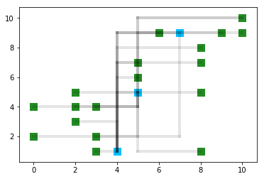

```python
import matplotlib.pyplot as plt
%matplotlib inline
import random


class Person:
    def __init__(self):
        #eine neue Person wird initialisiert

        #sie bekommt eine zufällig Heimadresse
        self.home = [random.randint(0,10),random.randint(0,10)]
        #und eine Arbeitsadresse aus einer Liste
        self.work = random.choice([[5,5],[5,5],[5,5],[4,1],[4,1],[7,9]])

    def zeichnen(self):
        #Die Personen zeichnen ihre Heimatadresse
        #s ist die Größe des Markers, die Form "s" steht für square
        plt.scatter(self.home[0],self.home[1], s = 100, marker = "s", c = "forestgreen")
        #Und ihren Arbeitsort
        plt.scatter(self.work[0],self.work[1], s = 100, marker = "s", c = "deepskyblue")

    def fahren(self):
        #Wir zeichnen zwei Linien:
        #Linie 1 geht in der x-Richtung von home nach work, y bleibt konstant bei home
        #Linie 2 geht in y-Richtung von home nach work, x bleibt konstant bei work
        plt.plot([self.home[0],self.work[0]],[self.home[1],self.home[1]],c = "black", alpha = 0.1, lw = 4)
        plt.plot([self.work[0],self.work[0]],[self.home[1],self.work[1]],c = "black", alpha = 0.1, lw = 4)


#----Hier startet das Hauptprogramm----

#Wir erstellen eine leere Liste
allepersonen=[]

#Wir fügen neue Personen
for it in range(20):
    allepersonen.append(Person())

for p in allepersonen:
    p.zeichnen()
    p.fahren()
```

Noch mehr Informationen über das Verkehrssystem würden wir erhalten, wenn wir die zurückgelegte **Gesamtstrecke** berechnen würden. Dazu werden wir in einem ersten Schritt eine Methode einbauen, die zu jeder Person die Länge des Arbeitsweges ausgibt.

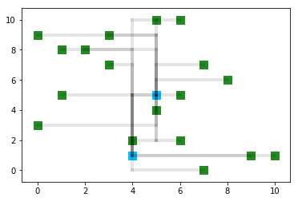

```python
import matplotlib.pyplot as plt
%matplotlib inline
import random


class Person:
    def __init__(self):
        #eine neue Person wird initialisiert

        #sie bekommt eine zufällig Heimadresse
        self.home = [random.randint(0,10),random.randint(0,10)]
        #und eine Arbeitsadresse aus einer Liste
        self.work = random.choice([[5,5],[5,5],[5,5],[4,1],[4,1],[7,9]])

    def zeichnen(self):
        #Die Personen zeichnen ihre Heimatadresse
        #s ist die Größe des Markers, die Form "s" steht für square
        plt.scatter(self.home[0],self.home[1], s = 100, marker = "s", c = "forestgreen")
        #Und ihren Arbeitsort
        plt.scatter(self.work[0],self.work[1], s = 100, marker = "s", c = "deepskyblue")

    def fahren(self):
        #Wir zeichnen zwei Linien:
        #Linie 1 geht in der x-Richtung von home nach work, y bleibt konstant bei home
        #Linie 2 geht in y-Richtung von home nach work, x bleibt konstant bei work
        plt.plot([self.home[0],self.work[0]],[self.home[1],self.home[1]],c = "black", alpha = 0.1, lw = 4)
        plt.plot([self.work[0],self.work[0]],[self.home[1],self.work[1]],c = "black", alpha = 0.1, lw = 4)

    def arbeitsweg(self):
        #der Weg errechnet sieh hier aus dem Abstand in x-Richtung + dem Abstand in y-Richtung
        dist = abs(self.home[0]-self.work[0]) + abs(self.home[1]-self.work[1])
        return dist


#----Hier startet das Hauptprogramm----

#Wir erstellen eine leere Liste
allepersonen=[]

#Wir fügen neue Personen
for it in range(20):
    allepersonen.append(Person())

for p in allepersonen:
    p.zeichnen()
    p.fahren()
```

Nun schreiben wir noch eine Function, die uns **alle Strecken aufsummiert** und die Summe auf den Bildschirm ausgibt. Achtung: Diese Function ist **keine Methode der Klasse**, denn eine einzelne Person kann nicht über die Strecken aller anderen Personen bescheidwissen. Deswegen ist die Defintion dieser Funktion nicht eingerückt, also nicht teil der Klasse:

```
Gesamtstrecke:
116
```

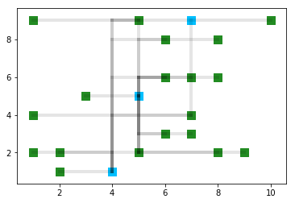

```python
import matplotlib.pyplot as plt
%matplotlib inline
import random


class Person:
    def __init__(self):
        #eine neue Person wird initialisiert

        #sie bekommt eine zufällig Heimadresse
        self.home = [random.randint(0,10),random.randint(0,10)]
        #und eine Arbeitsadresse aus einer Liste
        self.work = random.choice([[5,5],[5,5],[5,5],[4,1],[4,1],[7,9]])

    def zeichnen(self):
        #Die Personen zeichnen ihre Heimatadresse
        #s ist die Größe des Markers, die Form "s" steht für square
        plt.scatter(self.home[0],self.home[1], s = 100, marker = "s", c = "forestgreen")
        #Und ihren Arbeitsort
        plt.scatter(self.work[0],self.work[1], s = 100, marker = "s", c = "deepskyblue")

    def fahren(self):
        #Wir zeichnen zwei Linien:
        #Linie 1 geht in der x-Richtung von home nach work, y bleibt konstant bei home
        #Linie 2 geht in y-Richtung von home nach work, x bleibt konstant bei work
        plt.plot([self.home[0],self.work[0]],[self.home[1],self.home[1]],c = "black", alpha = 0.1, lw = 4)
        plt.plot([self.work[0],self.work[0]],[self.home[1],self.work[1]],c = "black", alpha = 0.1, lw = 4)

    def arbeitsweg(self):
        #der Weg errechnet sieh hier aus dem Abstand in x-Richtung + dem Abstand in y-Richtung
        dist = abs(self.home[0]-self.work[0]) + abs(self.home[1]-self.work[1])
        return dist

def gesamtstrecke():
    #wir berechnen die Gesamtstrecke
    gesamt = 0
    #Wir gehen in einer Schleife über alle Personen
    for p in allepersonen:
        #und summieren die Arbeitswege
        gesamt = gesamt + p.arbeitsweg()

    print("Gesamtstrecke:")
    print(gesamt)

#----Hier startet das Hauptprogramm----

#Wir erstellen eine leere Liste
allepersonen=[]

#Wir fügen neue Personen
for it in range(20):
    allepersonen.append(Person())

for p in allepersonen:
    p.zeichnen()
    p.fahren()

gesamtstrecke()
```

Hier steht nun die Gesamtstrecke über dem Plot, obwohl wir die `gesamtstrecke` erst danach aufrufen. Das hat damit zu tun, dass Python standardmäßig mit den Plots wartet und sie erst auf den Bildschirm gibt, wenn alle anderen Berechnungen fertig sind. Mit dem Befehl `plt.show()` können wir einen **Plot sofort anzeigen** lassen.

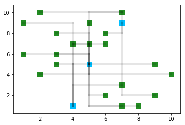

```
Gesamtstrecke:
111
```

```python
import matplotlib.pyplot as plt
%matplotlib inline
import random


class Person:
    def __init__(self):
        #eine neue Person wird initialisiert

        #sie bekommt eine zufällig Heimadresse
        self.home = [random.randint(0,10),random.randint(0,10)]
        #und eine Arbeitsadresse aus einer Liste
        self.work = random.choice([[5,5],[5,5],[5,5],[4,1],[4,1],[7,9]])

    def zeichnen(self):
        #Die Personen zeichnen ihre Heimatadresse
        #s ist die Größe des Markers, die Form "s" steht für square
        plt.scatter(self.home[0],self.home[1], s = 100, marker = "s", c = "forestgreen")
        #Und ihren Arbeitsort
        plt.scatter(self.work[0],self.work[1], s = 100, marker = "s", c = "deepskyblue")

    def fahren(self):
        #Wir zeichnen zwei Linien:
        #Linie 1 geht in der x-Richtung von home nach work, y bleibt konstant bei home
        #Linie 2 geht in y-Richtung von home nach work, x bleibt konstant bei work
        plt.plot([self.home[0],self.work[0]],[self.home[1],self.home[1]],c = "black", alpha = 0.1, lw = 4)
        plt.plot([self.work[0],self.work[0]],[self.home[1],self.work[1]],c = "black", alpha = 0.1, lw = 4)

    def arbeitsweg(self):
        #der Weg errechnet sieh hier aus dem Abstand in x-Richtung + dem Abstand in y-Richtung
        dist = abs(self.home[0]-self.work[0]) + abs(self.home[1]-self.work[1])
        return dist

def gesamtstrecke():
    #wir berechnen die Gesamtstrecke
    gesamt = 0
    #Wir gehen in einer Schleife über alle Personen
    for p in allepersonen:
        #und summieren die Arbeitswege
        gesamt = gesamt + p.arbeitsweg()

    print("Gesamtstrecke:")
    print(gesamt)

#----Hier startet das Hauptprogramm----

#Wir erstellen eine leere Liste
allepersonen=[]

#Wir fügen neue Personen
for it in range(20):
    allepersonen.append(Person())

for p in allepersonen:
    p.zeichnen()
    p.fahren()

plt.show()

gesamtstrecke()
```

Nun möchten wir versuchen, ob wir diesen Verkehrssystem noch ein wenig **optimieren** können. Viele Personen leben weit weg von ihrem Arbeitsort und könnten sich durch Umziehen viel Strecke sparen. Schreiben wir also eine Methode, die den **Heimatort einer Person probeweise ändert**. Sollte sich der Arbeitsweg dadurch verlängert haben, wird die Änderung wieder rückgängig gemacht.

Diese Methode sollte aus 3 Teilen bestehen: Zuerst merken wir uns die aktuelle Strecke und Heimatadresse. Dann ändern wir die Heimatadresse auf einen neuen zufälligen Wert. Im letzten Schritt wird die Änderung rückgängig gemacht, wenn sie unvorteilhaft war (dafür benötigen wir die Informationen über alte Strecke und Heimatadresse).

Wir definieren diese Methode und geben unseren Personen dann 10 mal die Chance umzuziehen. Danach wiederholen wir den Plot und die Streckenberechnung, um zu sehen welchen Effekt diese Änderung hatte.

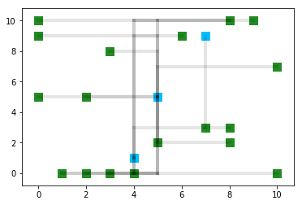

```
Gesamtstrecke:
141
```

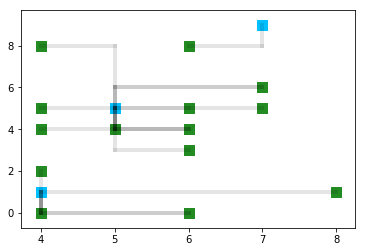

```
Gesamtstrecke:
42
```

```python
import matplotlib.pyplot as plt
%matplotlib inline
import random


class Person:
    def __init__(self):
        #eine neue Person wird initialisiert

        #sie bekommt eine zufällig Heimadresse
        self.home = [random.randint(0,10),random.randint(0,10)]
        #und eine Arbeitsadresse aus einer Liste
        self.work = random.choice([[5,5],[5,5],[5,5],[4,1],[4,1],[7,9]])

    def zeichnen(self):
        #Die Personen zeichnen ihre Heimatadresse
        #s ist die Größe des Markers, die Form "s" steht für square
        plt.scatter(self.home[0],self.home[1], s = 100, marker = "s", c = "forestgreen")
        #Und ihren Arbeitsort
        plt.scatter(self.work[0],self.work[1], s = 100, marker = "s", c = "deepskyblue")

    def fahren(self):
        #Wir zeichnen zwei Linien:
        #Linie 1 geht in der x-Richtung von home nach work, y bleibt konstant bei home
        #Linie 2 geht in y-Richtung von home nach work, x bleibt konstant bei work
        plt.plot([self.home[0],self.work[0]],[self.home[1],self.home[1]],c = "black", alpha = 0.1, lw = 4)
        plt.plot([self.work[0],self.work[0]],[self.home[1],self.work[1]],c = "black", alpha = 0.1, lw = 4)

    def arbeitsweg(self):
        #der Weg errechnet sieh hier aus dem Abstand in x-Richtung + dem Abstand in y-Richtung
        dist = abs(self.home[0]-self.work[0]) + abs(self.home[1]-self.work[1])
        return dist

    def umziehen(self):
        #Methode um den Heimatort zu wechseln

        #wir speichern den aktuellen Weg und den aktuellen Heimatort
        alterweg = self.arbeitsweg()
        oldhome = self.home

        #die Person zieht auf ein zufällige Position um
        self.home = [random.randint(0,10),random.randint(0,10)]

        #Wenn der Weg dadurch länger geworden ist...
        if self.arbeitsweg() > alterweg:
            #... wird die Änderung rückgängig gemacht
            self.home = oldhome


def gesamtstrecke():
    #wir berechnen die Gesamtstrecke
    gesamt = 0
    #Wir gehen in einer Schleife über alle Personen
    for p in allepersonen:
        #und summieren die Arbeitswege
        gesamt = gesamt + p.arbeitsweg()

    print("Gesamtstrecke:")
    print(gesamt)


#----hier beginnt das eigentliche Programm----


#Wir erstellen eine leere Liste
allepersonen=[]

#Wir fügen neue Personen
for it in range(20):
    allepersonen.append(Person())

#Wir iterieren über alle Personen
for p in allepersonen:
    #Jede Person benutzt die Methode zeichnen und fahren
    p.zeichnen()
    p.fahren()

#Der Plot wird angezeigt
plt.show()
#Die Gesamtstrecke wird berechnet
gesamtstrecke()

#Wir lassen die Personen umziehen
for it in range(10):
    for p in allepersonen:
        p.umziehen()


#Eine neue Figur wird erstellt
plt.figure()

#Wieder wird gezeichnet und die Gesamtstrecke berechnet
for p in allepersonen:
    p.zeichnen()
    p.fahren()
plt.show()
gesamtstrecke()
```

Dieses Modell könnten wir nun natürlich beliebig erweitern. Wir können **neue Methoden und Eigenschaften** einbauen, oder die bestehenden verfeinern. Methoden können (gleich wie Functions) auch mehrere Inputwerte haben. Natürlich kann ein Programm auch mehrere verschiedene Klassen beinhalten.

Ein großer Vorteil von Klassen und Objekten: Das Hauptprogramm bleibt immer **sehr gut lesbar** und es gibt eine strikte Trennung von was passieren soll (Hauptprogramm) und wie es passieren soll (Methoden und Functions). Somit kann man ein Hauptprogramm meist benutzen, ohne dass man die einzelnen Functions und Methoden bis ins letzte Detail verstehen muss.

Dieses Konzept ist mehr oder weniger das **Grundkonzept von modernem Programmieren**: Schon von Anfang an haben wir zum Beispiel mit der Function `plot` Grafiken erstellt und Elemente zu einem Objekt der Klasse Liste hinzugefügt, ohne dass wir uns je mit der genauen Definition dieser Klassen beschäftigen mussten. Das Verwenden von vorgefertigen Functions, Klassen und sogar ganzen Bibliotheken und packages macht modernes Programmieren überhaupt erst möglich.

## Zusammenfassung

### Klassen und Objekte

In Python können wir **Klassen** definieren und dann **Objekte** erstellen, die diesen Klassen angehören. Jede Klasse wird durch `class NameDerKlasse:` definiert und hat eine **Initialisierungs-Methode** namens `__init__` die dann vom Hauptprogramm mit dem Namen der Klasse aufgerufen wird. Durch diese Methode wird ein neues Objekt dieser Klasse erstellt, das unter einem Namen oder in einer Liste gespeichert werden kann.

### Methoden und Eigenschaften

**Eigenschaften** sind Variablen, die alle Objekte von einer Klasse haben. So hat zum Beispiel jedes Objekt der Klasse "Person" in unserem Beispiel einen Heimatort. Diese Eigenschaften werden meistens **in der Initialisierungsmethode erstellt** und gespeichert. Eigenschaften werden innerhalb der Definitionen mit `self.NameDerEigenschaft` aufgerufen und verwändert. Außerhalb der Definition muss man auch angeben auf welches Objekt der Klasse man sich bezieht, also `NameDesObjekts.NameDerEigenschaft`.

**Methoden** sind sozusagen **Functions innerhalb von Klassen**. Sie können Input- und Outputvariablen haben und werden ähnlich wie übliche Functions definiert. Die erste Inputvariable ist bei Methoden jedoch immer `self`.

Methoden werden innerhalb einer Klassendefinition mit `NameDerMethode(self,inputA,inputB,inputC,...):` definiert und dann im Haupprogramm mit `NameDesObjekts.NameDerMethode(inputA,inputB,inputC,...)` aufgerufen. Man beachte, dass man beim Aufrufen kein `self` mehr benötigt, da der Name des Objekts schon vor dem Punkt steht.

### Schnelles Iterieren

Schleifen, die über eine **Liste von Objekten** laufen und im i-ten Schritt das i-te Objekt aufrufen um etwas damit zu machen, lassen sich verkürzt schreiben. Statt

`for it in range(20):`

$\ \ \ \ \ \ $`Befehl für Objekt das unter listenname[it] gespeichert ist`

kann man immer

`for obj in listenname:`

$\ \ \ \ \ \ $`Befehl für obj`

schreiben, wobei `obj` eine frei wählbare Bezeichnung ist.

# Kapitel 12 - Ein einfaches makroskopisches Verkehrsmodell

In diesem Kapitel nutzen wir unser Wissen über Klassen und andere Pythonstrukturen um ein einfaches Verkehrsmodell zu erstellen. Wir möchten herausfinden wie viele direkte (und für e-Autos auch indirekte) Emissionen Fahrzeuge verursachen und einige Szenarios durchrechnen.

Beginnen werden wir mit einer einfachen Klasse namens `Car`. Fürs erste soll diese Klasse nur einen Initialisierungsmethode bekommen und 3 Eigenschaften haben: `age`, `size` und `distance`. Diese drei Größen sind die Argumente der Initialisierungsmethode. Danach erstellen wir ein Testobjekt dieser Klasse und lassen uns die Eigenschaften wieder ausgeben.

```python
class Car:
    def __init__(self, age, size, distance):
        self.age = age
        self.size = size
        self.distance = distance
testcar = Car(2,"m",5000)

print(testcar.age,testcar.size,testcar.distance)
```

```
2 m 5000
```

Das nächste was für uns relevante wäre, wären die CO2-Emissionen des Autos, die es pro Kilometer verursacht. Diese Eigenschaft werden wir aber nicht einfach einlesen, sondern aus den vorhandenen Informationen (also Größe und Alter) abschätzen. Dazu erstellen wir eine eigene Methode. Die Zahlenwerte, die wir angenommen haben orientieren sich an [Hofer, Jäger, Füllsack: Large scale simulation of CO2 emissions caused by urban car traffic](https://www.researchgate.net/publication/323147233_Large_scale_simulation_of_CO2_emissions_caused_by_urban_car_traffic_An_agent-based_network_approach).

```python
class Car:
    def __init__(self, age, size, distance):
        self.age = age
        self.size = size
        self.distance = distance
        self.calcemissions()


    def calcemissions(self):
        if self.size == "s":
            self.emissions = 120 * (1 + age * 0.02) #g/km
        elif self.size == "m":
            self.emissions = 140 * (1 + age * 0.02)
        elif self.size == "l":
            self.emissions = 180 * (1 + age * 0.02)

testcar = Car(2,"m",5000)

print(testcar.age,testcar.size,testcar.distance,testcar.emissions)
```

```
2 m 5000 151.24681834894383
```

Hier müssen wir aber wieder vorsichtig sein: Wenn unter Size etwas steht, was wir nicht erwarten (wie z.B. "groß" oder "👶"), überspringen wir alle ifs und die Eigenschaft `emissions` wird nicht gesetzt. Wir brauchen also eine Fehlermeldung, die auf dieses Problem hinweist, um zu verhindern, dass wir mit fehlenden oder falschen Daten weiterarbeiten.

```python
class Car:
    def __init__(self, age, size, distance):
        self.age = age
        self.size = size
        self.distance = distance
        self.calcemissions()


    def calcemissions(self):
        if self.size == "s":
            self.emissions = 120 * (1 + age * 0.02) #g/km
        elif self.size == "m":
            self.emissions = 140 * (1 + age * 0.02)
        elif self.size == "l":
            self.emissions = 180 * (1 + age * 0.02)
        else:
            raise Exception("Unknown car size: " + str(self.size) )

testcar = Car(2,"👶",5000)

print(testcar.age,testcar.size,testcar.distance,testcar.emissions)
```

```
---------------------------------------------------------------------------
Exception                                 Traceback (most recent call last)
<ipython-input-227-e17ed964b143> in <module>()
     17             raise Exception("Unknown car size: " + str(self.size) )
     18
---> 19 testcar = Car(2,"👶",5000)
     20
     21 print(testcar.age,testcar.size,testcar.distance,testcar.emissions)

<ipython-input-227-e17ed964b143> in __init__(self, age, size, distance)
      4         self.size = size
      5         self.distance = distance
----> 6         self.calcemissions()
      7
      8

<ipython-input-227-e17ed964b143> in calcemissions(self)
     15             self.emissions = 180 * (1 + age * 0.02)
     16         else:
---> 17             raise Exception("Unknown car size: " + str(self.size) )
     18
     19 testcar = Car(2,"👶",5000)

Exception: Unknown car size: 👶
```

Nun, wo wir jedem Fahrzeug einen Emissionswert zuweisen können, können wir auch eine Methode bauen, die diesen Wert zurückgibt. Das ist alles was wir brauchen, um die Gesamtemissionen einer Fahrzeugflotte zu berechnen.

Um die Methode zu testen, erstellen wir auch gleich eine Population an Fahrzeugen.

```python
import random


class Car:
    def __init__(self, age, size, distance):
        self.age = age
        self.size = size
        self.distance = distance
        self.calcemissions()


    def calcemissions(self):
        if self.size == "s":
            self.emissions = 120 * (1 + age * 0.02) #g/km
        elif self.size == "m":
            self.emissions = 140 * (1 + age * 0.02)
        elif self.size == "l":
            self.emissions = 180 * (1 + age * 0.02)
        else:
            raise Exception("Unknown car size: " + str(self.size) )

    def reportemissions(self):
        return self.distance * self.emissions



def makepopulation (distmean,diststd):
    allcars = []


    for it in range(10000):
        age = random.uniform(0,20)
        dist = random.gauss(distmean,diststd)
        size = random.choice(["s","m","l"])
        allcars.append(Car(age,size,dist))
    return allcars


distmean = 5500
diststd = 50



#overall emissions
allcars = makepopulation(distmean, diststd)
em_sum = 0
for car in allcars:
    em_sum = em_sum + car.reportemissions()

print(em_sum / 1000 / 10000, "kg pro Person")
```

```
869.6788068315942 kg pro Person
```

Mit diesen neuen Methoden ist das Erstellen und Auswerten der Szenarien einfach:

```python
import random


class Car:
    def __init__(self, age, size, distance):
        self.age = age
        self.size = size
        self.distance = distance
        self.calcemissions()


    def calcemissions(self):
        if self.size == "s":
            self.emissions = 120 * (1 + age * 0.02) #g/km
        elif self.size == "m":
            self.emissions = 140 * (1 + age * 0.02)
        elif self.size == "l":
            self.emissions = 180 * (1 + age * 0.02)
        else:
            raise Exception("Unknown car size: " + str(self.size) )

    def reportemissions(self):
        return self.distance * self.emissions

    def buynewcar(self):
        self.age = 0
        self.calcemissions()

    def usebus(self):
        self.distance = self.distance / 10


def makepopulation (distmean,diststd):
    allcars = []


    for it in range(10000):
        age = random.uniform(0,20)
        dist = random.gauss(distmean,diststd)
        size = random.choice(["s","m","l"])
        allcars.append(Car(age,size,dist))
    return allcars



distmean = 5500
diststd = 50


#overall emissions
allcars = makepopulation(distmean, diststd)
em_sum = 0
for car in allcars:
    em_sum = em_sum + car.reportemissions()

print("Baseline:  ", em_sum / 1000 / 10000, "kg pro Person")

#Szenario 1: Autos älter als 10 Jahre werden ersetzt
allcars = makepopulation(distmean, diststd)
em_sum = 0
for car in allcars:
    if car.age > 10:
        car.buynewcar()
    em_sum = em_sum + car.reportemissions()

print("Szenario 1:",em_sum / 1000 / 10000, "kg pro Person")

#Szenario 2: 25% benutzen einen Bus
allcars = makepopulation(distmean, diststd)
em_sum = 0
for car in allcars:
    if random.uniform(0,100)<20:
        car.usebus()
    em_sum = em_sum + car.reportemissions()

print("Szenario 2:",em_sum / 1000 / 10000, "kg pro Person")
```

```
Baseline:   869.7388177600628 kg pro Person
Szenario 1: 872.9046779718418 kg pro Person
Szenario 2: 713.6243753931545 kg pro Person
```

Nun können wir noch Elektroautos in unser Modell einbauen. Das wirft eine interessante Frage auf: Können wir die Klasse `Car` auch für E-Autos verwenden? Dafür spricht, dass wir die meisten Eigenschaften und Methoden genau gleich verwenden könnten. Dagegen spricht, dass das Berechnen der Emissionen bei E-Autos anders funktioniert. Hier hilft uns das Konzept von **Erbschaft**. Wir können in Python, basierend auf eine Klasse, eine Unterklasse erstellen, die alle Eigenschaften und Methoden der ursprünglichen Klasse erbt, aber darüber hinaus auch noch weitere Eigenschaften und Methoden besitzen kann. Außerdem ist es möglich, exisitierende Methoden für die Unterklasse anzupassen.

In unserem Modell können wir also die Unterklasse `Ecar` erstellen, die alles von `Car` erbt, aber eine andere Methode `reportemissions` besitzt:

```python
class Ecar(Car):
    def reportemissions(self):
        return "noch unbekannt"
```

Wie man sieht ist diese Klassendefinition sehr schlank, da wir das meiste aus `Car` erben. Nun müssen wir uns nur mehr überlegen, wie wir die Emissionen des E-Autos berechnen. Die Sache ist natürlich ein wenig komplizierter, denn die Emissionen entstehen nicht direkt auf der Straße, sondern wo auch immer der Strom erzeugt wurde, mit dem das Fahrzeug geladen wurde. Es kommt also ganz stark auf den Energiemix an, der verwendet wurde.

Die gesuchte Methode wird also so aussehen, dass wir die Distanz mit einer Zahl multiplizieren, die uns sagt wie viel Emissionen pro Kilometer durch die Stromerzeugung entstanden sind. Das korrekt durchzuführen ist natürlich schwierig, aber mit einem **Life-Cycle-Assessement (LCA)** können wir zumindest unterschiedliche Arten Strom zu produzieren vergleichen. Das gibt uns auch Anhaltspunkte für eine grobe Abschätzung der verursachten Emissionen. Details zu diesem Prozess findet man zum Beispiel in [Turconi, Boldrin, Astrup](https://orbit.dtu.dk/files/118476742/2012_RSER_Turconi_Life_cycle_assessment_LCA_of_electricity_generation_technologies_overview_comparability_and_limitations_self_archive.pdf).

Hier nehmen wir einen Verbrauch von 0.2 kWh pro Kilometer an und vergleichen den Energiemix von Graz, Wien und den USA. Wir finden folgende Werte:

- Graz: 2.5 g/km | 90% Wasser (10g/kWh), 5% Wind (30g/kWh), 5% Biomasse(50g/kWh)|
- Wien: 45 g/km | 45% Wasser, 45% Erdgas (500g/kWh), 5% Wind, 5% Biomasse|
- USA: 100 g/km | 37% Öl (700g/kWh), 30% Gas (500g/kWh), 15% Kohle (800g/kWh), 10% Nuklear(20g/kWh), 8% renewable (30g/kWh)|

Diese Werte verwenden wir in der Methode `reportemissions`.

Um die E-Autos dann auch zu testen, müssen wir unsere Function `makepopulation` noch ein wenig anpassen. Wir benötigen zusätzlich den Prozentsatz der vorhandenen Elektroautos. Diese können wir für Österreich mit 0.4% abschätzen.

```python
import random


class Car:
    def __init__(self, age, size, distance):
        self.age = age
        self.size = size
        self.distance = distance
        self.calcemissions()


    def calcemissions(self):
        if self.size == "s":
            self.emissions = 120 * (1 + age * 0.02) #g/km
        elif self.size == "m":
            self.emissions = 140 * (1 + age * 0.02)
        elif self.size == "l":
            self.emissions = 180 * (1 + age * 0.02)
        else:
            raise Exception("Unknown car size: " + str(self.size) )

    def reportemissions(self):
        return self.distance * self.emissions

    def buynewcar(self):
        self.age = 0
        self.calcemissions()

    def usebus(self):
        self.distance = self.distance / 10

class Ecar(Car):
    def reportemissions(self):
        return self.distance * emix

def makepopulation (echance,distmean,diststd):
    allcars = []


    for it in range(10000):
        age = random.uniform(0,20)
        dist = random.gauss(distmean,diststd)
        size = random.choice(["s","m","l"])
        if random.uniform(0,100)<echance:
            allcars.append(Ecar(age,size,dist))
        else:
            allcars.append(Car(age,size,dist))
    return allcars



emix = 2.5  #GRAZ: 90% Wasser (10g/kWh), 5% Wind (30g/kWh), 5% Biomasse(50g/kWh)
#emix = 45  #WIEN: 45% Wasser, 45% Erdgas (500g/kWh), 5% Wind, 5% Biomasse
#emix = 100 #USA: 37% Öl (700g/kWh), 30% Gas (500g/kWh), 15% Kohle (800g/kWh), 10% Nuklear(20g/kWh), 8% renewable (30g/kWh)

echance = 0.4
distmean = 5500
diststd = 50



#overall emissions
allcars = makepopulation(echance, distmean, diststd)
em_sum = 0
for car in allcars:
    em_sum = em_sum + car.reportemissions()

print("Baseline:  ", em_sum / 1000 / 10000, "kg pro Person")

#Szenario 1: Autos älter als 10 Jahre werden ersetzt
allcars = makepopulation(echance, distmean, diststd)
em_sum = 0
for car in allcars:
    if car.age > 10:
        car.buynewcar()
    em_sum = em_sum + car.reportemissions()

print("Szenario 1:",em_sum / 1000 / 10000, "kg pro Person")

#Szenario 2: 25% benutzen einen Bus
allcars = makepopulation(echance, distmean, diststd)
em_sum = 0
for car in allcars:
    if random.uniform(0,100) < 20:
        car.usebus()
    em_sum = em_sum + car.reportemissions()

print("Szenario 2:",em_sum / 1000 / 10000, "kg pro Person")
```

```
Baseline:   866.7936403430951 kg pro Person
Szenario 1: 869.8223364537947 kg pro Person
Szenario 2: 712.3889638111342 kg pro Person
```

Somit ist es uns gelungen ein ganz einfaches, makroskopisches Verkehrsmodell in Python zu bauen. Dies lässt sich natürlich beliebig erweitern. Die Befehle und Strukturen die auftreten, werden jedoch auch bei äußerst komplexen Programmen die selben bleiben: Wenn man Klassen, Functions, Schleifen, Abfragen und Datentypen verstanden hat, kann man prinzipiell jedes nur denkbare Programm schreiben.

## Zusammenfassung

### Initialisierungsmethoden mit Argumenten

Initialisierungsmethoden können auch Argumente verlangen. Das ist völlig analog zu Functions mit

`def __init__(self,arg1,arg2,arg3)`

möglich. Diese Argumente (ohne `self`) müssen dann aber auch beim Erstellen eines Objekts übergeben werden:

`obj = NameDerKlasse(arg1,arg2,arg3)`

### Erbschaft bei Klassen

Wenn man eine neue Klasse erstellen möchte, die auf einer existierenden Klasse basieren soll, gibt es das Konzept der **Erbschaft**. Damit können wir alle Methoden und Eigenschaften der Grundklasse übernehmen, diese aber ändern und ausbauen.

`Class NameDerNeuenKlasse(NameDerGrundklasse):`

## Kapitel 13 - Visualisierungen

Egal, was programmiert werden soll, ob ein Modell erstellt wird, eine Simulation durchgeführt oder statistische Daten ausgewertet werden: am Ende sollen die Ergebnisse meist visualisiert werden. Die Darstellung von Ergebnissen - das "Plotten" - ist oft ebenso wichtig, wie die Ergebnisse selbst und es gibt unzählige Arten des Visualisierens.

Einige wichtige Regeln zum Erstellen von Grafiken sollten, unabhängig von der Art der Darstellung, immer beachtet werden:

- alle Achsen sollten beschriftet sein
- wenn möglich sollte im Plot ersichtlich sein, welche Einheiten verwendet werden
- alle relevanten Größen sollten erkennbar sein
- Farben sollten so gewählt werden, dass sie auch in Graustufen gut unterscheidbar sind. Alternativ können Markierungen verwendet werden.

Im Folgenden geben wir eine Übersicht über die gängigsten Arten, Ergebnisse zu visualisieren. Einige davon haben wir bereits kennengelernt, anderen sind wir noch nicht begegnet.

Eine Übersicht über alle Farben, die in Matplotlib einen Eigennamen haben finden Sie hier: https://matplotlib.org/examples/color/named_colors.html

### Der Linienplot

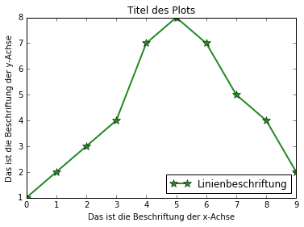

```python
import matplotlib.pyplot as plt
%matplotlib inline

testdaten = [1, 2, 3, 4, 7, 8, 7, 5, 4, 2]
plt.xlabel("Das ist die Beschriftung der x-Achse")
plt.ylabel("Das ist die Beschriftung der y-Achse")
plt.title("Titel des Plots")

plt.plot(testdaten, color = "forestgreen", lw = 2, marker = "*", markersize = 10, label = "Linienbeschriftung")
plt.legend(loc = "best")
```

Ein Linienplot ist eine der einfachsten Arten, Daten zu visualisieren. Immer wenn man eine Größe (z.B. Anzahl der Frösche) hat, die man gegen eine andere Größe auftragen möchte (z.B. Zeit) bietet sich ein Linienplot an.

### Der Fill-Plot

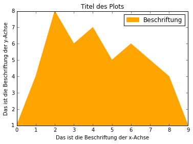

```python
import matplotlib.pyplot as plt
%matplotlib inline

testdaten = [1, 4, 8, 6, 7, 5, 6, 5, 4, 1]
plt.xlabel("Das ist die Beschriftung der x-Achse")
plt.ylabel("Das ist die Beschriftung der y-Achse")
plt.title("Titel des Plots")

plt.fill(testdaten, color = "orange", label = "Beschriftung")
plt.legend(loc = "best")
```

Der Fill-Plot ist konzeptionell ähnlich wie der Linienplot, nur möchte man hier eher auf die Fläche unter der Kurve hinweisen, als auf die Kurve selbst.

### Der Stackplot

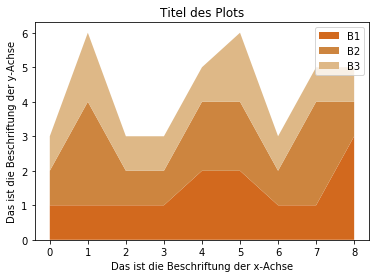

```python
import matplotlib.pyplot as plt
%matplotlib inline

testdaten = [1, 1, 1, 1, 2, 2, 1, 1, 3]
testdaten2 = [1, 3, 1, 1, 2, 2, 1, 3, 1]
testdaten3 = [1, 2, 1, 1, 1, 2, 1, 1, 1]

plt.xlabel("Das ist die Beschriftung der x-Achse")
plt.ylabel("Das ist die Beschriftung der y-Achse")
plt.title("Titel des Plots")

plt.stackplot(range(len(testdaten)), testdaten, testdaten2, testdaten3, labels = ("B1","B2","B3"),
              colors=["chocolate","peru","burlywood"])
plt.legend(loc = "best")
```

Beim Stackplot können wir mehrere Fill-Plots übereinanderstapeln. Der Stackplot ist relativ schwer zu lesen, da man ihn leicht mit einem Linienplot verwechselt. In unserem Beispiel, würde man also fälschlicherweise glauben, dass die Größe B3 am Anfang den Wert 3 hat. In wirklichkeit ist der Plot aber so zu lesen: B3 geht von 2 bis 3, hat also den Wert 1. Auch Steigungen kann man in einem Stackplot nicht mehr korrekt ablesen. Stackplots sind also mit Vorsicht zu genießen. Wo sie aber doch Sinn machen, ist wenn man Größen hat, die sich immer auf eine gemeinsame Summe ergänzen. Zum Beispiel den prozentuellen Anteil einer gewissen Heiz-Technologie. Alle Technologien sollten sich immer auf 100% ergänzen:

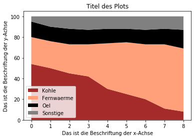

```python
import matplotlib.pyplot as plt
%matplotlib inline

tec1 = [54,50,45,42,30,25,20,11,8]
tec2 = [26,26,28,31,44,50,53,62,61]
tec3 = [15,14,15,14,14,13,14,15,18]
tec4 = [ 5,10,12,13,12,12,13,12,13]
plt.xlabel("Das ist die Beschriftung der x-Achse")
plt.ylabel("Das ist die Beschriftung der y-Achse")
plt.title("Titel des Plots")

plt.stackplot(range(len(tec1)), tec1, tec2, tec3, tec4, labels=("Kohle","Fernwaerme","Oel","Sonstige"),
              colors = ["brown","lightsalmon","black","gray"])
plt.legend(loc = "lower left")
```

### Der Scatterplot

Alle bisherigen Plots hatten mehr oder weniger das gleiche Anwendungsgebiet: Wir möchten eine Größe $y$ (Anzahl der Frösche) einer anderen Größe $x$ (Zeit) eindeutig zuordnen. Was aber, wenn diese Zuordnung nicht eindeutig ist. Was ist, wenn wir die Frösche wiegen und ihr Alter bestimmen wollen. In diesem Fall ist es nicht so, dass wir jedem Alter ein exaktes Gewicht zuordnen können: Frösche mit gleichem Alter können unterschiedliches Gewicht haben, und Frösche mit unterschiedlichem Alter könnten durchaus das gleiche Gewicht haben. Was passiert also, wenn wir alle Frösche im Teich wiegen, und sowohl ihr Alter als auch ihr Gewicht grafisch darstellen wollen? Versuchen wir zuerst einen Linienplot.

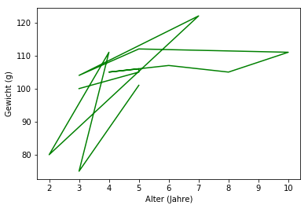

```python
import matplotlib.pyplot as plt
%matplotlib inline

# Die Daten sind wie folgt aufgebaut:
# froschgewicht = (gewicht von frosch1, gewicht von frosch2, gewicht von frosch3, ...)
# froschalter = (alter von frosch1, alter von frosch2, alter von frosch3, ...)
froschgewicht = (100,105,106,105,107,105,111,112,104,122,80,111,75,101)
froschalter = (3, 5, 5, 4, 6, 8, 10, 5, 3, 7, 2, 4, 3, 5)
plt.plot(froschalter, froschgewicht, color = "green")
plt.xlabel("Alter (Jahre)")
plt.ylabel("Gewicht (g)")
```

Dieser Plot ist prinzipiell nicht falsch, er ist nur sehr verwirrend. Die Verbindungslinien suggerieren, dass die Frösche, die zufällig nacheinander gewogen wurden, irgendetwas miteinander zu tun hätten. Die Reihenfolge der Frösche hat in diesem Plot aber keine Bedeutung, die Frösche hätten auch in ganz anderer Reihenfolge gewogen werden können. Um diesen Plot zu reparieren, sollten wir also die Verbundungslinien entfernen und einfach nur für jeden Frosch eine Markierung vornehmen. Damit entsteht ein so genannter **Scatter-Plot**.

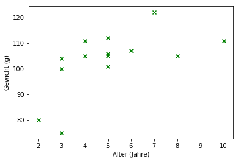

```python
import matplotlib.pyplot as plt
%matplotlib inline

# Die Daten sind wie folgt aufgebaut:
# froschgewicht = (gewicht von frosch1, gewicht von frosch2, gewicht von frosch3, ...)
# froschalter = (alter von frosch1, alter von frosch2, alter von frosch3, ...)
froschgewicht = (100,105,106,105,107,105,111,112,104,122,80,111,75,101)
froschalter= (3, 5, 5, 4, 6, 8, 10, 5, 3, 7, 2, 4, 3, 5)
plt.scatter(froschalter, froschgewicht, color = "green", marker = "x")
plt.xlabel("Alter (Jahre)")
plt.ylabel("Gewicht (g)")
```

### Das Kuchendiagramm

Ein Klassiker unter den Visualisierungen, der sehr gut geeignet ist, um prozentuelle Anteile darzustellen, ist das Kuchen- oder auch Tortendiagramm. Als wissenschaftliches Diagramm ist es nur bedingt geeignet, da man konkrete Größen nur schwer ablesen kann. Für Präsentationen, oder um sich einen groben Überblick über Daten zu verschaffen, eignet es sich aber recht gut:

```
(-1.1098228888537658,
 1.3062803190020018,
 -1.1130371722185557,
 1.1255162745181304)
```

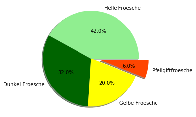

```python
import matplotlib.pyplot as plt
%matplotlib inline

labels = ('Helle Froesche', 'Dunkel Froesche', 'Gelbe Froesche', 'Pfeilgiftfroesche')
farben = ("lightgreen","darkgreen","yellow", "orangered")
anzahl = [42, 32, 20, 6]
explode = (0, 0, 0, 0.2)  # Hervorgehoben werden nur Pfeilgiftfrösche

plt.pie(anzahl, explode = explode, labels = labels, autopct = '%1.1f%%',
        shadow = True, colors = farben)
plt.axis('equal')  # macht den Plot quadratisch
```

### Subplots

Oft möchte man mehrere Grafiken nebeneinander darstellen. Dafür eignen sich so genannte `subplots`. Die Syntax dafür ist ein wenig gewöhnungsbedürftig. Subplots werden immer mit drei Zahlen definiert, wobei zum Beispiel die Zahlenfolge (2, 3, 4) - oder alternativ auch einfach (234) - bedeutet, dass sämtliche Plots, die dargestellt werden sollen, in 2 Zeilen und 3 Spalten angordnet werden und aktuell (mit der letzten Zahl 4) der 4te von 6 Plots (2 mal 3) angesprochen wird.

Beim Definieren von Subplots wird oftmals mit `fig = plt.figure(figsize=(10, 3))` zunächst eine allgemeine Zeichenfläche festgelegt. `figsize` definiert dabei die Größe der gesamten Zeichenfläche und der Befehl `subplots_adjust(hspace = 0.5)`erlaubt es, die Abstände zwischen den Subplots zu definieren, hier zum Beispiel die Höhenabstände (`hspace`). Mit Befehlen wie `ax1 = fig.add_subplot(2, 3, 1)` wird sodann der jeweilige Subplot in diese allgemeine Zeichenfläche eingefügt - hier also der Subplot `ax1` an die erste Stelle der Plots.

Merke: wenn statt der `matplotlib.pyplot`-Abkürzung `plt` ein eigener Plotname definiert wird, wie hier etwa `ax1`, so müssen sämtliche Plot-Beschriftungen mit `set_` vorgenommen werden, also zum Beispiel `ax1.set_title('Plot 1')`.

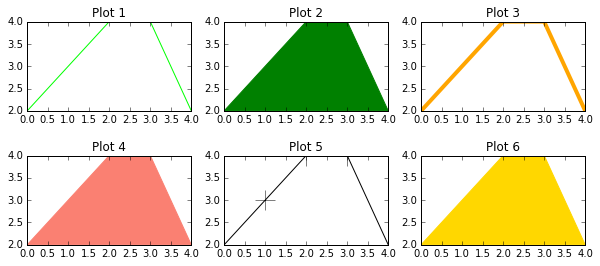

```python
import matplotlib.pyplot as plt
%matplotlib inline

testdaten=[2,3,4,4,2]

# definiere eine allgemeine Zeichenfläche
fig = plt.figure(figsize=(10, 4))
# lege Höhenabstände zwischen den Subplots fest
plt.subplots_adjust(hspace = 0.5)

# füge ersten Subplot zur allgemeinen Zeichenfläche hinzu
ax1 = fig.add_subplot(2, 3, 1)
ax1.plot(testdaten, color = "lime")
ax1.set_title('Plot 1')
# zweiter Subplot
ax2 = fig.add_subplot(2, 3, 2)
ax2.fill(testdaten, color = "green")
ax2.set_title('Plot 2')
# dritter Subplot
ax3 = fig.add_subplot(2, 3, 3)
ax3.plot(testdaten, color = "orange", lw=4)
ax3.set_title('Plot 3')
# vierter Subplot
ax4 = fig.add_subplot(2, 3, 4)
ax4.fill(testdaten, color = "salmon")
ax4.set_title('Plot 4')
# fünfter Subplot
ax5 = fig.add_subplot(2, 3, 5)
ax5.plot(testdaten, color = "black", marker="+", ms=20)
ax5.set_title('Plot 5')
# sechster Subplot
ax6 = fig.add_subplot(2, 3, 6)
ax6.fill(testdaten, color = "gold")
ax6.set_title('Plot 6')
```

### Das Polardiagramm

Das Polardiagramm sieht zwar ähnlich aus, wie ein Kuchendiagramm, hat aber eine grundlegend andere Bedeutung. Wichtig ist hier der Winkel: jedem Winkel (0 - 360 Grad) wird eine bestimmte Größe zugeordnet. In der Physik wird dieser Plot zum Beispiel verwendet, um darzustellen, in welche Richtung ein Objekt wie viel Strahlung emittiert. Als einfacheres Beispiel könnte man damit auch das Sichtfeld verschiedener Tiere vergleichen:

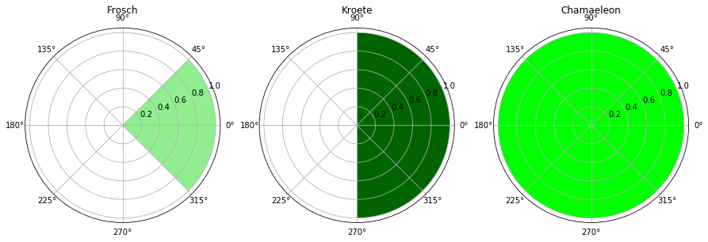

```python
import matplotlib.pyplot as plt
%matplotlib inline

# definiere eine allgemeine Zeichenfläche
fig = plt.figure(figsize=(15,5))
# füge einen Sub-Plot in die allgemeine Zeichenfläche ein, als ersten in einer ein-reihigen Zeile mit drei Plätzen = (1, 3, 1)
ax1 = fig.add_subplot(1, 3, 1, projection='polar')
# der Plot wird als Polarplot initialisiert
ax1.bar(0, 1, 3.1415/2, bottom = 0.0, color = "lightgreen")
# Für einen Polarplot lautet die Syntax:
# plt.bar(Um wieviel Grad ist die Fläche zentriert, Radius der Fläsche, welchen Winkel hat die Fläche)
# Beachte: Die Winkel werden hier nicht in Grad, sondern als Bogenmaß angegeben,
# also 360° = 2 * pi ~ 2 * 3.1415
ax1.set_title("Frosch")  # Beachte: mit subplot muss die Beschriftung mit set_ erfolgen, also zB set_title

# füge einen weiteren Sub-Plot hinzu, als zweiten in einer ein-reihigen Zeile mit drei Plätzen = (1, 3, 2)
ax2 = fig.add_subplot(1, 3, 2, projection='polar')
ax2.bar(0, 1, 3.1415, bottom = 0.0, color = "darkgreen")
ax2.set_title("Kroete")

# füge noch einen weiteren Sub-Plot hinzu, als dritten in einer ein-reihigen Zeile mit drei Plätzen = (1, 3, 3)
ax3 = fig.add_subplot(1, 3, 3, projection='polar')
ax3.bar(0, 1, 2 * 3.1415, bottom = 0.0, color = "lime")
ax3.set_title("Chamaeleon")
```

### Histogramme

Histogramme eigenen sich, um darzustellen, wie oft ein gewisser Wert in einer Liste vorkommt. Nehmen wir an, wir wissen, dass es eine Bevölkerungsexplosion in unserem Froschteich gab, wir wissen aber nicht genau, in welchem Jahr sie stattgefunden hat. Um diese Frage zu beantworten, fangen wir alle Frösche im Teich und bestimmen ihr Alter. Um unsere Forschungsfrage zu beantworten, stellen wir die resultierende Liste sodann als Histogramm dar:

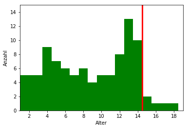

```python
import matplotlib.pyplot as plt
%matplotlib inline

froschalter=(15,16,15,17,14,13,11,14,14,12,13,1,1,2,3,4,4,5,6,2,1,1,1,3,4,5,14,14,10,10,14,14,11,11,14,
             14,13,12,14,13,12,11,11,10,7,6,8,9,13,13,13,13,5,4,3,2,4,5,6,7,8,12,12,9,4,12,2,3,4,5,6,7,8,9,10,10,
            6,7,8,4,5,9,8,2,3,4,5,6,7,8,13,13,12,12,13,13,13,19,18)

# Syntax: plt.hist(Liste, Anzahl der Balken, kleinster und größter Wert, Farbe)
plt.hist(froschalter, 18, range = (0.5, 18.5), color = "green")
plt.xlim(1,19)
plt.ylim(0,15)

# zeichne eine rote Vertikale, um die Bevölkerungsexplosion vor ca 15 Jahren zu markieren
plt.plot((14.5, 14.5),(0, 16), color = "red", lw = 3)
plt.ylabel("Anzahl")
plt.xlabel("Alter")
```

Wir erkennen aus dem Histogramm, dass viele Frösche im Teich aktuell 14 Jahre alt sind, aber nur sehr sehr wenige 15 Jahre. Vor 14 Jahren wurden also wesentlich mehr Frösche geboren, als vor 15 Jahren. Die Bevölkerungsexplosion fand also offensichtlich vor ca 15 Jahren statt.

### Box- und Violinplots

Sehr ähnlich sind Violinplots, mit dem Unterscheid, dass sie detailliertere Informationen zur Verteilung liefern. Ähnlich dem Histogramm zeigen sie (stark geglättet), in welchen Bereichen viele, und in welchen wenige Werte vorliegen.

Im folgenden vergleichen wir das Gewicht der Frösche in 3 verschiedenen Teichen, einmal mit Box- und einmal mit Violinplots:

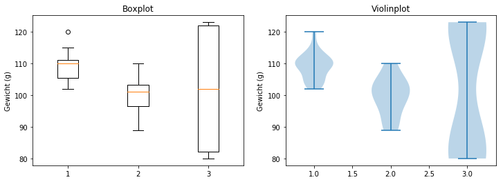

```python
import matplotlib.pyplot as plt
%matplotlib inline

teich1=(110,105,106,104,110,115,113,112,113,103,104,110,109,108,105,102,110,110,110,111,109,111,120)
teich2=(90,99,100,102,103,103,104,102,110,90,95,98,97,93,98,110,105,106,102,89)
teich3=(120,122,123,122,120,122,123,122,119,80,85,80,81,82,83,82,84,85)

fig = plt.figure(figsize=(12,4))
# erster Plot
ax1 = fig.add_subplot(1, 2, 1)
ax1.boxplot((teich1, teich2, teich3))
ax1.set_title("Boxplot")
ax1.set_ylabel("Gewicht (g)")

# zweiter Plot
ax2 = fig.add_subplot(1, 2, 2)
ax2.violinplot((teich1, teich2, teich3))
ax2.set_title("Violinplot")
ax2.set_ylabel("Gewicht (g)")
```

### Heatmaps

Beim plotten drei-dimensionaler Daten möchte man in der Regel jedem $x/y$-Daten-Paar einen weiteren $z$-Wert zuweisen, so wie etwa den Geo-Koordinaten auf topologischen Karten eine Seehöhe zugewiesen wird. Um diese Plots eindrucksvoll darzustellen, importieren wir im Folgenden vorgefertige Beispieldaten aus dem `matplotlib.cbook` mit dem Befehl `get_sample_data`.

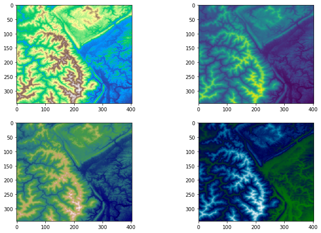

```python
import matplotlib.pyplot as plt
%matplotlib inline
# importiere Beispielsdaten
from matplotlib.cbook import get_sample_data
import numpy as np

data = np.load(get_sample_data('jacksboro_fault_dem.npz')) # liest einen Beispieldatensatz ein
z = data['elevation'] # speichert die Höheninformation des Datensatzes unter z

fig = plt.figure(figsize=(12, 8))
ax1 = fig.add_subplot(2, 2, 1)
ax1.imshow(z, cmap = plt.cm.terrain)    # colormap terrain: z.B. für Karten
ax2 = fig.add_subplot(2, 2, 2)
ax2.imshow(z, cmap = plt.cm.viridis)    # colormap viridis: für abstrakte Daten
ax3 = fig.add_subplot(2, 2, 3)
ax3.imshow(z, cmap = plt.cm.gist_earth) # colormap earth: für realistische Karten
ax4 = fig.add_subplot(2, 2, 4)
ax4.imshow(z, cmap = plt.cm.ocean)      # colormap ocean: Blautöne Für Meeresdarstellungen
```

### Weitere Visualisierungen

Neben den hier vorgestellten Möglichkeiten gibt es noch viele mehr, um Daten zu visualisieren. Einen guten Überblick liefert die Plot-Gallerie von `matplotlib` unter https://matplotlib.org/gallery.html, die zu jedem Plot auch den Code bereitstellt, mit dem der Plot erzeugt wird.

Darüber hinaus gibt es auch andere spezialisierte Python-Pakete, die sich der Datenvisualisierung widmen. Beispiele sind `seaborn`, zum Darstellen von statistischen Daten, oder `bokeh`, das interaktive Visualisierungen im Browser erlaubt.

## Zusammenfassung

### Linienplots

Linienplots sind einfache Plots, die immer dann verwendet werden, wenn eine Größe eindeutig einer anderen Größe zugeordnet werden soll.

### Histogramme, Box- und Violinplots

Mit Histogrammen, sowie Box- oder Violinplots werden Verteilungen dargestellt. Während ein Histogramm eine exakte Verteilung darstellt, lassen sich mit Box- und Violinplots mehrere Verteilungen miteinander vergleichen. Boxplots zeigen wichtige Charakteristika deutliche (Mittelwert, Standardabweichung, Ausreißer), Violinplots zeigen mehr Details der Verteilung.

### Subplots

Subplots erlauben es, mehrere Grafiken nebeneinander darzustellen. Subplots werden immer mit drei Zahlen bezeichnet: `subplot(a, b, c)`, wobei die Grafiken in einer Matrix mit $a$ Zeilen und $b$ Spalten organisiert sind und der jeweils gerade angesprochene Plot den Index $c$ hat.

# Kapitel 14 - Daten verarbeiten mit Pandas

Python lässt sich auch sehr gut dazu nutzen große Datenmengen zu analysieren und zu bearbeiten. Ganz egal wie die Daten vorliegen (csv, excel,...), viele Datentypen lassen sich importieren und weiterverarbeiten. Das Pythonpaket, das man üblichweise dazu verwendet nennt sich `pandas`.

Wir werden in Folge pandas ein wenig kennenlernen, indem wir den World Happiness Report untersuchen. Diesen Datensatz, und noch viele viele weitere, findet man zum Beispiel frei verfügbar auf [Kaggle](https://www.kaggle.com/). Dort gibt es auch Datensätze über [alle Apps im Google Play Store](https://www.kaggle.com/lava18/google-play-store-apps), [Filme](https://www.kaggle.com/tmdb/tmdb-movie-metadata), [Börsendaten](https://www.kaggle.com/borismarjanovic/price-volume-data-for-all-us-stocks-etfs) [Development Indikatoren](https://www.kaggle.com/worldbank/world-development-indicators) oder die [Oberflächentemperatur der Erde](https://www.kaggle.com/berkeleyearth/climate-change-earth-surface-temperature-data).

Zuerst werden wir den Datensatz importieren. Das funktioniert einerseits mit Daten auf der eigenen Festplatte, andererseits aber auch mit Datein im Internet:

```python
import pandas as pd
import matplotlib.pyplot as plt
%matplotlib inline

url="https://s3.amazonaws.com/happiness-report/2018/WHR2018Chapter2OnlineData.xls"

df=pd.read_excel(url)
```

Nun sind die Daten des World-Happiness-Report 2018 unter `df` gespeichert. Diese Abkürzung steht für DataFrame, das ist der Datentyp den Pandas benutzt. Man kann ihn sich wie eine Excel-Tabelle vorstellen: Die Daten sind nach Zeilen und Spalten sortiert und können als Einträge entweder Zahlen oder Zeichenketten besitzen.

Da der Datensatz relativ groß ist, macht es wenig Sinn alle Daten auf einmal zu printen. Um aber trotzdem einen Einblick in den Datensatz zu bekommen, und zu bestätigen, dass das Einlesen funktioniert hat, kann man den Befehl `head` benutzen, um sich die ersten paar Einträge des Datensatzes anzeigen zu lassen.

```python
df.head()
```

|  | country | year | Life Ladder | Log GDP per capita | Social support | Healthy life expectancy at birth | Freedom to make life choices | Generosity | Perceptions of corruption | Positive affect | Negative affect | Confidence in national government | Democratic Quality | Delivery Quality | Standard deviation of ladder by country-year | Standard deviation/Mean of ladder by country-year | GINI index (World Bank estimate) | GINI index (World Bank estimate), average 2000-15 | gini of household income reported in Gallup, by wp5-year |
| --- | --- | --- | --- | --- | --- | --- | --- | --- | --- | --- | --- | --- | --- | --- | --- | --- | --- | --- | --- |
| 0 | Afghanistan | 2008 | 3.723590 | 7.168690 | 0.450662 | 49.209663 | 0.718114 | 0.181819 | 0.881686 | 0.517637 | 0.258195 | 0.612072 | -1.929690 | -1.655084 | 1.774662 | 0.476600 | NaN | NaN | NaN |
| 1 | Afghanistan | 2009 | 4.401778 | 7.333790 | 0.552308 | 49.624432 | 0.678896 | 0.203614 | 0.850035 | 0.583926 | 0.237092 | 0.611545 | -2.044093 | -1.635025 | 1.722688 | 0.391362 | NaN | NaN | 0.441906 |
| 2 | Afghanistan | 2010 | 4.758381 | 7.386629 | 0.539075 | 50.008961 | 0.600127 | 0.137630 | 0.706766 | 0.618265 | 0.275324 | 0.299357 | -1.991810 | -1.617176 | 1.878622 | 0.394803 | NaN | NaN | 0.327318 |
| 3 | Afghanistan | 2011 | 3.831719 | 7.415019 | 0.521104 | 50.367298 | 0.495901 | 0.175329 | 0.731109 | 0.611387 | 0.267175 | 0.307386 | -1.919018 | -1.616221 | 1.785360 | 0.465942 | NaN | NaN | 0.336764 |
| 4 | Afghanistan | 2012 | 3.782938 | 7.517126 | 0.520637 | 50.709263 | 0.530935 | 0.247159 | 0.775620 | 0.710385 | 0.267919 | 0.435440 | -1.842996 | -1.404078 | 1.798283 | 0.475367 | NaN | NaN | 0.344540 |

So sehen wir schon, welche Daten hier auftreten. Jede Zeile beinhaltet den Namen des Landes und das Jahr, gefolgt von vielen möglichen Indikatoren von Glücklichkeit, wie zum Beispiel die Lebenserwartung oder das Vertrauen in die Regierung.

Einen genaueren Überblick erhalten wir mit dem Befehl `describe`:

```python
df.describe()
```

|  | year | Life Ladder | Log GDP per capita | Social support | Healthy life expectancy at birth | Freedom to make life choices | Generosity | Perceptions of corruption | Positive affect | Negative affect | Confidence in national government | Democratic Quality | Delivery Quality | Standard deviation of ladder by country-year | Standard deviation/Mean of ladder by country-year | GINI index (World Bank estimate) | GINI index (World Bank estimate), average 2000-15 | gini of household income reported in Gallup, by wp5-year |
| --- | --- | --- | --- | --- | --- | --- | --- | --- | --- | --- | --- | --- | --- | --- | --- | --- | --- | --- |
| count | 1562.000000 | 1562.000000 | 1535.000000 | 1549.000000 | 1553.000000 | 1533.000000 | 1482.000000 | 1472.000000 | 1544.000000 | 1550.000000 | 1401.000000 | 1391.000000 | 1391.000000 | 1562.000000 | 1562.000000 | 583.000000 | 1386.000000 | 1205.000000 |
| mean | 2011.820743 | 5.433676 | 9.220822 | 0.810669 | 62.249887 | 0.728975 | 0.000079 | 0.753622 | 0.708969 | 0.263171 | 0.480207 | -0.126617 | 0.004947 | 2.003501 | 0.387271 | 0.372846 | 0.386948 | 0.445204 |
| std | 3.419787 | 1.121017 | 1.184035 | 0.119370 | 7.960671 | 0.145408 | 0.164202 | 0.185538 | 0.107644 | 0.084006 | 0.190724 | 0.873259 | 0.981052 | 0.379684 | 0.119007 | 0.086609 | 0.083694 | 0.105410 |
| min | 2005.000000 | 2.661718 | 6.377396 | 0.290184 | 37.766476 | 0.257534 | -0.322952 | 0.035198 | 0.362498 | 0.083426 | 0.068769 | -2.448228 | -2.144974 | 0.863034 | 0.133908 | 0.241000 | 0.228833 | 0.223470 |
| 25% | 2009.000000 | 4.606351 | 8.310665 | 0.748304 | 57.299580 | 0.633754 | -0.114313 | 0.697359 | 0.621471 | 0.204116 | 0.334732 | -0.772010 | -0.717463 | 1.737934 | 0.309722 | 0.307000 | 0.321583 | 0.368531 |
| 50% | 2012.000000 | 5.332600 | 9.398610 | 0.833047 | 63.803192 | 0.748014 | -0.022638 | 0.808115 | 0.717398 | 0.251798 | 0.463137 | -0.225939 | -0.210142 | 1.960345 | 0.369751 | 0.349000 | 0.371000 | 0.425395 |
| 75% | 2015.000000 | 6.271025 | 10.190634 | 0.904329 | 68.098228 | 0.843628 | 0.094649 | 0.880089 | 0.800858 | 0.311515 | 0.610723 | 0.665944 | 0.717996 | 2.215920 | 0.451833 | 0.433500 | 0.433104 | 0.508579 |
| max | 2017.000000 | 8.018934 | 11.770276 | 0.987343 | 76.536362 | 0.985178 | 0.677773 | 0.983276 | 0.943621 | 0.704590 | 0.993604 | 1.540097 | 2.184725 | 3.527820 | 1.022769 | 0.648000 | 0.626000 | 0.961435 |

Dieser Befehl rechnet uns für jede Spalte relevante Indikatoren aus, wie zum Beispiel die Zahl der Einträge (count), den Mittelwert (mean), die Standardabweichung (std), aber auch detailiertere Informatioen über die Verteilung. Spalten wo diese Berechnugen nicht möglich sind (z.B. Name das Landes) werden ausgelassen. Somit sehen wir zum Beispiel, dass die mittlere gesunde Lebenserwartung bei etwa 62 Jahren liegt, es aber auch zumindest einen Eintrag in der Datenbank gibt, wo dieser Wert unter 40 Jahren liegt. Es wäre natürlich besonders interessant herauszufinden, welche Einträge das sind.

Solche Abfragen (also alle Zeilen, wo die Spalte X einen Wert von Y oder kleiner hat) sind mit Pandas sehr einfach möglich.